# Project: Identify Customer Segments

In this project, you will apply unsupervised learning techniques to identify segments of the population that form the core customer base for a mail-order sales company in Germany. These segments can then be used to direct marketing campaigns towards audiences that will have the highest expected rate of returns. The data that you will use has been provided by our partners at Bertelsmann Arvato Analytics, and represents a real-life data science task.

This notebook will help you complete this task by providing a framework within which you will perform your analysis steps. In each step of the project, you will see some text describing the subtask that you will perform, followed by one or more code cells for you to complete your work. **Feel free to add additional code and markdown cells as you go along so that you can explore everything in precise chunks.** The code cells provided in the base template will outline only the major tasks, and will usually not be enough to cover all of the minor tasks that comprise it.

It should be noted that while there will be precise guidelines on how you should handle certain tasks in the project, there will also be places where an exact specification is not provided. **There will be times in the project where you will need to make and justify your own decisions on how to treat the data.** These are places where there may not be only one way to handle the data. In real-life tasks, there may be many valid ways to approach an analysis task. One of the most important things you can do is clearly document your approach so that other scientists can understand the decisions you've made.

At the end of most sections, there will be a Markdown cell labeled **Discussion**. In these cells, you will report your findings for the completed section, as well as document the decisions that you made in your approach to each subtask. **Your project will be evaluated not just on the code used to complete the tasks outlined, but also your communication about your observations and conclusions at each stage.**

```python
# import libraries here; add more as necessary
import numpy as np
import pandas as pd
import matplotlib.pyplot as plt
import seaborn as sns

from sklearn.preprocessing import Imputer, StandardScaler
from sklearn.decomposition import PCA
from sklearn.cluster import KMeans
import pprint
import random

# magic word for producing visualizations in notebook
%matplotlib inline
```

### Step 0: Load the Data

There are four files associated with this project (not including this one):

- `Udacity_AZDIAS_Subset.csv`: Demographics data for the general population of Germany; 891211 persons (rows) x 85 features (columns).
- `Udacity_CUSTOMERS_Subset.csv`: Demographics data for customers of a mail-order company; 191652 persons (rows) x 85 features (columns).
- `Data_Dictionary.md`: Detailed information file about the features in the provided datasets.
- `AZDIAS_Feature_Summary.csv`: Summary of feature attributes for demographics data; 85 features (rows) x 4 columns

Each row of the demographics files represents a single person, but also includes information outside of individuals, including information about their household, building, and neighborhood. You will use this information to cluster the general population into groups with similar demographic properties. Then, you will see how the people in the customers dataset fit into those created clusters. The hope here is that certain clusters are over-represented in the customers data, as compared to the general population; those over-represented clusters will be assumed to be part of the core userbase. This information can then be used for further applications, such as targeting for a marketing campaign.

To start off with, load in the demographics data for the general population into a pandas DataFrame, and do the same for the feature attributes summary. Note for all of the `.csv` data files in this project: they're semicolon (`;`) delimited, so you'll need an additional argument in your [`read_csv()`](https://pandas.pydata.org/pandas-docs/stable/generated/pandas.read_csv.html) call to read in the data properly. Also, considering the size of the main dataset, it may take some time for it to load completely.

Once the dataset is loaded, it's recommended that you take a little bit of time just browsing the general structure of the dataset and feature summary file. You'll be getting deep into the innards of the cleaning in the first major step of the project, so gaining some general familiarity can help you get your bearings.

```python
# Load in the general demographics data.
azdias = pd.read_csv('Udacity_AZDIAS_Subset.csv', delimiter=';')

# Load in the feature summary file.
feat_info = pd.read_csv('AZDIAS_Feature_Summary.csv', delimiter=';')
```

```python
# Check the structure of the data after it's loaded (e.g. print the number of
# rows and columns, print the first few rows).

print('Shape of azdias dataset : {}'.format(azdias.shape))
print('Number of rows : {}'.format(azdias.shape[0]))
print('Number of columns : {}'.format(azdias.shape[1]))
azdias.head()
```

```
Shape of azdias dataset : (891221, 85)
Number of rows : 891221
Number of columns : 85
```

|  | AGER_TYP | ALTERSKATEGORIE_GROB | ANREDE_KZ | CJT_GESAMTTYP | FINANZ_MINIMALIST | FINANZ_SPARER | FINANZ_VORSORGER | FINANZ_ANLEGER | FINANZ_UNAUFFAELLIGER | FINANZ_HAUSBAUER | ... | PLZ8_ANTG1 | PLZ8_ANTG2 | PLZ8_ANTG3 | PLZ8_ANTG4 | PLZ8_BAUMAX | PLZ8_HHZ | PLZ8_GBZ | ARBEIT | ORTSGR_KLS9 | RELAT_AB |
| --- | --- | --- | --- | --- | --- | --- | --- | --- | --- | --- | --- | --- | --- | --- | --- | --- | --- | --- | --- | --- | --- |
| 0 | -1 | 2 | 1 | 2.0 | 3 | 4 | 3 | 5 | 5 | 3 | ... | NaN | NaN | NaN | NaN | NaN | NaN | NaN | NaN | NaN | NaN |
| 1 | -1 | 1 | 2 | 5.0 | 1 | 5 | 2 | 5 | 4 | 5 | ... | 2.0 | 3.0 | 2.0 | 1.0 | 1.0 | 5.0 | 4.0 | 3.0 | 5.0 | 4.0 |
| 2 | -1 | 3 | 2 | 3.0 | 1 | 4 | 1 | 2 | 3 | 5 | ... | 3.0 | 3.0 | 1.0 | 0.0 | 1.0 | 4.0 | 4.0 | 3.0 | 5.0 | 2.0 |
| 3 | 2 | 4 | 2 | 2.0 | 4 | 2 | 5 | 2 | 1 | 2 | ... | 2.0 | 2.0 | 2.0 | 0.0 | 1.0 | 3.0 | 4.0 | 2.0 | 3.0 | 3.0 |
| 4 | -1 | 3 | 1 | 5.0 | 4 | 3 | 4 | 1 | 3 | 2 | ... | 2.0 | 4.0 | 2.0 | 1.0 | 2.0 | 3.0 | 3.0 | 4.0 | 6.0 | 5.0 |

5 rows × 85 columns

```python
azdias.info()
```

```
<class 'pandas.core.frame.DataFrame'>
RangeIndex: 891221 entries, 0 to 891220
Data columns (total 85 columns):
AGER_TYP                 891221 non-null int64
ALTERSKATEGORIE_GROB     891221 non-null int64
ANREDE_KZ                891221 non-null int64
CJT_GESAMTTYP            886367 non-null float64
FINANZ_MINIMALIST        891221 non-null int64
FINANZ_SPARER            891221 non-null int64
FINANZ_VORSORGER         891221 non-null int64
FINANZ_ANLEGER           891221 non-null int64
FINANZ_UNAUFFAELLIGER    891221 non-null int64
FINANZ_HAUSBAUER         891221 non-null int64
FINANZTYP                891221 non-null int64
GEBURTSJAHR              891221 non-null int64
GFK_URLAUBERTYP          886367 non-null float64
GREEN_AVANTGARDE         891221 non-null int64
HEALTH_TYP               891221 non-null int64
LP_LEBENSPHASE_FEIN      886367 non-null float64
LP_LEBENSPHASE_GROB      886367 non-null float64
LP_FAMILIE_FEIN          886367 non-null float64
LP_FAMILIE_GROB          886367 non-null float64
LP_STATUS_FEIN           886367 non-null float64
LP_STATUS_GROB           886367 non-null float64
NATIONALITAET_KZ         891221 non-null int64
PRAEGENDE_JUGENDJAHRE    891221 non-null int64
RETOURTYP_BK_S           886367 non-null float64
SEMIO_SOZ                891221 non-null int64
SEMIO_FAM                891221 non-null int64
SEMIO_REL                891221 non-null int64
SEMIO_MAT                891221 non-null int64
SEMIO_VERT               891221 non-null int64
SEMIO_LUST               891221 non-null int64
SEMIO_ERL                891221 non-null int64
SEMIO_KULT               891221 non-null int64
SEMIO_RAT                891221 non-null int64
SEMIO_KRIT               891221 non-null int64
SEMIO_DOM                891221 non-null int64
SEMIO_KAEM               891221 non-null int64
SEMIO_PFLICHT            891221 non-null int64
```

[output cut: 35 more lines]

```
ONLINE_AFFINITAET        886367 non-null float64
REGIOTYP                 770025 non-null float64
KBA13_ANZAHL_PKW         785421 non-null float64
PLZ8_ANTG1               774706 non-null float64
PLZ8_ANTG2               774706 non-null float64
PLZ8_ANTG3               774706 non-null float64
PLZ8_ANTG4               774706 non-null float64
PLZ8_BAUMAX              774706 non-null float64
PLZ8_HHZ                 774706 non-null float64
PLZ8_GBZ                 774706 non-null float64
ARBEIT                   794005 non-null float64
ORTSGR_KLS9              794005 non-null float64
RELAT_AB                 794005 non-null float64
dtypes: float64(49), int64(32), object(4)
memory usage: 578.0+ MB
```

```python
# Check the structure of the featue summary dataset after it's loaded (e.g. print the number of
# rows and columns, print the first few rows).

print('Shape of azdias_feature_summary dataset : {}'.format(feat_info.shape))
print('Number of rows : {}'.format(feat_info.shape[0]))
print('Number of columns : {}'.format(feat_info.shape[1]))
feat_info.head()
```

```
Shape of azdias_feature_summary dataset : (85, 4)
Number of rows : 85
Number of columns : 4
```

|  | attribute | information_level | type | missing_or_unknown |
| --- | --- | --- | --- | --- |
| 0 | AGER_TYP | person | categorical | [-1,0] |
| 1 | ALTERSKATEGORIE_GROB | person | ordinal | [-1,0,9] |
| 2 | ANREDE_KZ | person | categorical | [-1,0] |
| 3 | CJT_GESAMTTYP | person | categorical | [0] |
| 4 | FINANZ_MINIMALIST | person | ordinal | [-1] |

> **Tip**: Add additional cells to keep everything in reasonably-sized chunks! Keyboard shortcut `esc --> a` (press escape to enter command mode, then press the 'A' key) adds a new cell before the active cell, and `esc --> b` adds a new cell after the active cell. If you need to convert an active cell to a markdown cell, use `esc --> m` and to convert to a code cell, use `esc --> y`.

## Step 1: Preprocessing

### Step 1.1: Assess Missing Data

The feature summary file contains a summary of properties for each demographics data column. You will use this file to help you make cleaning decisions during this stage of the project. First of all, you should assess the demographics data in terms of missing data. Pay attention to the following points as you perform your analysis, and take notes on what you observe. Make sure that you fill in the **Discussion** cell with your findings and decisions at the end of each step that has one!

#### Step 1.1.1: Convert Missing Value Codes to NaNs

The fourth column of the feature attributes summary (loaded in above as `feat_info`) documents the codes from the data dictionary that indicate missing or unknown data. While the file encodes this as a list (e.g. `[-1,0]`), this will get read in as a string object. You'll need to do a little bit of parsing to make use of it to identify and clean the data. Convert data that matches a 'missing' or 'unknown' value code into a numpy NaN value. You might want to see how much data takes on a 'missing' or 'unknown' code, and how much data is naturally missing, as a point of interest.

**As one more reminder, you are encouraged to add additional cells to break up your analysis into manageable chunks.**

```python
# Finding out the columns with naturally missing data
azdias.isnull().any()
```

```
AGER_TYP                 False
ALTERSKATEGORIE_GROB     False
ANREDE_KZ                False
CJT_GESAMTTYP             True
FINANZ_MINIMALIST        False
FINANZ_SPARER            False
FINANZ_VORSORGER         False
FINANZ_ANLEGER           False
FINANZ_UNAUFFAELLIGER    False
FINANZ_HAUSBAUER         False
FINANZTYP                False
GEBURTSJAHR              False
GFK_URLAUBERTYP           True
GREEN_AVANTGARDE         False
HEALTH_TYP               False
LP_LEBENSPHASE_FEIN       True
LP_LEBENSPHASE_GROB       True
LP_FAMILIE_FEIN           True
LP_FAMILIE_GROB           True
LP_STATUS_FEIN            True
LP_STATUS_GROB            True
NATIONALITAET_KZ         False
PRAEGENDE_JUGENDJAHRE    False
RETOURTYP_BK_S            True
SEMIO_SOZ                False
SEMIO_FAM                False
SEMIO_REL                False
SEMIO_MAT                False
SEMIO_VERT               False
SEMIO_LUST               False
                         ...
OST_WEST_KZ               True
WOHNLAGE                  True
CAMEO_DEUG_2015           True
CAMEO_DEU_2015            True
CAMEO_INTL_2015           True
KBA05_ANTG1               True
KBA05_ANTG2               True
KBA05_ANTG3               True
KBA05_ANTG4               True
KBA05_BAUMAX              True
KBA05_GBZ                 True
BALLRAUM                  True
EWDICHTE                  True
INNENSTADT                True
GEBAEUDETYP_RASTER        True
KKK                       True
MOBI_REGIO                True
ONLINE_AFFINITAET         True
REGIOTYP                  True
KBA13_ANZAHL_PKW          True
PLZ8_ANTG1                True
PLZ8_ANTG2                True
PLZ8_ANTG3                True
PLZ8_ANTG4                True
PLZ8_BAUMAX               True
PLZ8_HHZ                  True
PLZ8_GBZ                  True
ARBEIT                    True
ORTSGR_KLS9               True
RELAT_AB                  True
Length: 85, dtype: bool
```

```python
# Quanitfying the naturally missing data in descenindg order
null_data = azdias.isnull().sum()[azdias.isnull().sum() > 0]

data_dict = {'count': null_data.values, 'pct': np.round(null_data.values *100/azdias.shape[0],2)}

azdias_init_null = pd.DataFrame(data=data_dict, index=null_data.index)
azdias_init_null.sort_values(by='count', ascending=False, inplace=True)
azdias_init_null
```

|  | count | pct |
| --- | --- | --- |
| KK_KUNDENTYP | 584612 | 65.60 |
| KBA05_BAUMAX | 133324 | 14.96 |
| KBA05_ANTG4 | 133324 | 14.96 |
| KBA05_ANTG1 | 133324 | 14.96 |
| KBA05_ANTG2 | 133324 | 14.96 |
| KBA05_GBZ | 133324 | 14.96 |
| MOBI_REGIO | 133324 | 14.96 |
| KBA05_ANTG3 | 133324 | 14.96 |
| KKK | 121196 | 13.60 |
| REGIOTYP | 121196 | 13.60 |
| PLZ8_ANTG1 | 116515 | 13.07 |
| PLZ8_ANTG3 | 116515 | 13.07 |
| PLZ8_ANTG4 | 116515 | 13.07 |
| PLZ8_BAUMAX | 116515 | 13.07 |
| PLZ8_HHZ | 116515 | 13.07 |
| PLZ8_GBZ | 116515 | 13.07 |
| PLZ8_ANTG2 | 116515 | 13.07 |
| W_KEIT_KIND_HH | 107602 | 12.07 |
| KBA13_ANZAHL_PKW | 105800 | 11.87 |
| CAMEO_DEU_2015 | 98979 | 11.11 |
| CAMEO_DEUG_2015 | 98979 | 11.11 |
| CAMEO_INTL_2015 | 98979 | 11.11 |
| ARBEIT | 97216 | 10.91 |
| ORTSGR_KLS9 | 97216 | 10.91 |
| RELAT_AB | 97216 | 10.91 |
| ANZ_HH_TITEL | 97008 | 10.88 |
| BALLRAUM | 93740 | 10.52 |
| EWDICHTE | 93740 | 10.52 |
| INNENSTADT | 93740 | 10.52 |
| GEBAEUDETYP_RASTER | 93155 | 10.45 |
| WOHNLAGE | 93148 | 10.45 |
| OST_WEST_KZ | 93148 | 10.45 |
| MIN_GEBAEUDEJAHR | 93148 | 10.45 |
| GEBAEUDETYP | 93148 | 10.45 |
| ANZ_HAUSHALTE_AKTIV | 93148 | 10.45 |
| KONSUMNAEHE | 73969 | 8.30 |
| ANZ_PERSONEN | 73499 | 8.25 |
| SOHO_KZ | 73499 | 8.25 |
| TITEL_KZ | 73499 | 8.25 |
| ALTER_HH | 73499 | 8.25 |
| ANZ_TITEL | 73499 | 8.25 |
| WOHNDAUER_2008 | 73499 | 8.25 |
| HH_EINKOMMEN_SCORE | 18348 | 2.06 |
| ONLINE_AFFINITAET | 4854 | 0.54 |
| GFK_URLAUBERTYP | 4854 | 0.54 |
| RETOURTYP_BK_S | 4854 | 0.54 |
| LP_STATUS_GROB | 4854 | 0.54 |
| LP_STATUS_FEIN | 4854 | 0.54 |
| LP_FAMILIE_GROB | 4854 | 0.54 |
| LP_FAMILIE_FEIN | 4854 | 0.54 |
| LP_LEBENSPHASE_GROB | 4854 | 0.54 |
| LP_LEBENSPHASE_FEIN | 4854 | 0.54 |
| CJT_GESAMTTYP | 4854 | 0.54 |

```python
# Shape of azdias_init_null dataframe
azdias_init_null.shape
```

```
(53, 2)
```

```python
# Total number of naturally missing observations
np.sum(azdias_init_null['count'])
```

```
4896838
```

So, 53 columns have naturally missing data which is not encoded by the codes as mentioned in azdias_feature_summary.csv file. We can see that even before mapping missing_or_unknown values to NaN, column KK_KUNDENTYP has 65% missing values.

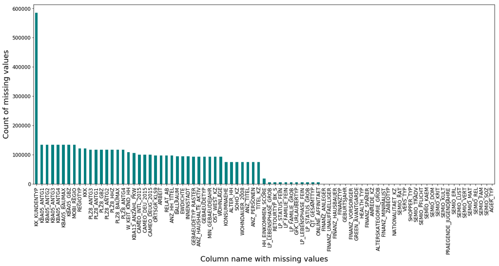

```python
# Visualizing the naturally missing data in the original azdias dataset.
azdias.isnull().sum().sort_values(ascending=False).plot.bar(figsize=(20,8),fontsize=12,color='teal');
plt.xlabel('Column name with missing values', fontsize=18)
plt.ylabel('Count of missing values', fontsize=18)
plt.show()
```

```python
# Making 'attribute' feature of feat_info dataframe as index of the feat_info to be helpful later on.
print(feat_info.columns[0])
feat_info.set_index(feat_info.columns[0], inplace=True)
feat_info.head()
```

```
attribute
```

| attribute | information_level | type | missing_or_unknown |
| --- | --- | --- | --- |
| AGER_TYP | person | categorical | [-1,0] |
| ALTERSKATEGORIE_GROB | person | ordinal | [-1,0,9] |
| ANREDE_KZ | person | categorical | [-1,0] |
| CJT_GESAMTTYP | person | categorical | [0] |
| FINANZ_MINIMALIST | person | ordinal | [-1] |

```python
# Printing out a column missing_or_unknown value and its type for a particular attribute.
print(feat_info.loc[['AGER_TYP'], ['missing_or_unknown']].missing_or_unknown.item())
print('Type of missing_or_unknown column value : {}'.format(type(feat_info.loc[['AGER_TYP'], ['missing_or_unknown']].missing_or_unknown.item())))


# Parsing missing_or_unknown column having string values to array of lists and storing it in new columnn nan_vals.
nan_vals = feat_info['missing_or_unknown'].str.replace('[','').str.replace(']','').str.split(',').values

# Adding nan_vals column to the dataframe.
feat_info['nan_vals'] = nan_vals
#print(type(feat_info))

# Printing out the value and type of value in nan_vals column for a particular attribute after parsing.
print(feat_info.loc[['AGER_TYP'], ['nan_vals']].nan_vals.item())
print('Type of nan_vals column value : {}'.format(type(feat_info.loc[['AGER_TYP'], ['nan_vals']].nan_vals.item())))
```

```
[-1,0]
Type of missing_or_unknown column value : <class 'str'>
['-1', '0']
Type of nan_vals column value : <class 'list'>
```

```python
feat_info.head()
```

| attribute | information_level | type | missing_or_unknown | nan_vals |
| --- | --- | --- | --- | --- |
| AGER_TYP | person | categorical | [-1,0] | [-1, 0] |
| ALTERSKATEGORIE_GROB | person | ordinal | [-1,0,9] | [-1, 0, 9] |
| ANREDE_KZ | person | categorical | [-1,0] | [-1, 0] |
| CJT_GESAMTTYP | person | categorical | [0] | [0] |
| FINANZ_MINIMALIST | person | ordinal | [-1] | [-1] |

```python
# Converting (list of string) values to (list of integers and string) in nan_vals column.

def is_int(value):
    try:
        int(value)
#        print('Integer : {}'.format(value))
        return True
    except ValueError:
#        print('Character : {}'.format(value))
        return False

feat_info['nan_vals'] = feat_info.apply(lambda x: [int(i) if is_int(i) else i for i in x['nan_vals']], axis=1)
```

```python
# Sanity check.
# Printing out the value and type of value in nan_vals column for a particular attribute after converting
# to list of integers and string

print(feat_info.loc[['AGER_TYP'], ['nan_vals']].nan_vals.item())
print('Type of nan_vals column value : {}'.format(type(feat_info.loc[['AGER_TYP'], ['nan_vals']].nan_vals.item())))
```

```
[-1, 0]
Type of nan_vals column value : <class 'list'>
```

```python
# Extracting the column names of azdias dataframe
col_names = azdias.columns
print(col_names)
```

```
Index(['AGER_TYP', 'ALTERSKATEGORIE_GROB', 'ANREDE_KZ', 'CJT_GESAMTTYP',
       'FINANZ_MINIMALIST', 'FINANZ_SPARER', 'FINANZ_VORSORGER',
       'FINANZ_ANLEGER', 'FINANZ_UNAUFFAELLIGER', 'FINANZ_HAUSBAUER',
       'FINANZTYP', 'GEBURTSJAHR', 'GFK_URLAUBERTYP', 'GREEN_AVANTGARDE',
       'HEALTH_TYP', 'LP_LEBENSPHASE_FEIN', 'LP_LEBENSPHASE_GROB',
       'LP_FAMILIE_FEIN', 'LP_FAMILIE_GROB', 'LP_STATUS_FEIN',
       'LP_STATUS_GROB', 'NATIONALITAET_KZ', 'PRAEGENDE_JUGENDJAHRE',
       'RETOURTYP_BK_S', 'SEMIO_SOZ', 'SEMIO_FAM', 'SEMIO_REL', 'SEMIO_MAT',
       'SEMIO_VERT', 'SEMIO_LUST', 'SEMIO_ERL', 'SEMIO_KULT', 'SEMIO_RAT',
       'SEMIO_KRIT', 'SEMIO_DOM', 'SEMIO_KAEM', 'SEMIO_PFLICHT', 'SEMIO_TRADV',
       'SHOPPER_TYP', 'SOHO_KZ', 'TITEL_KZ', 'VERS_TYP', 'ZABEOTYP',
       'ALTER_HH', 'ANZ_PERSONEN', 'ANZ_TITEL', 'HH_EINKOMMEN_SCORE',
       'KK_KUNDENTYP', 'W_KEIT_KIND_HH', 'WOHNDAUER_2008',
       'ANZ_HAUSHALTE_AKTIV', 'ANZ_HH_TITEL', 'GEBAEUDETYP', 'KONSUMNAEHE',
       'MIN_GEBAEUDEJAHR', 'OST_WEST_KZ', 'WOHNLAGE', 'CAMEO_DEUG_2015',
       'CAMEO_DEU_2015', 'CAMEO_INTL_2015', 'KBA05_ANTG1', 'KBA05_ANTG2',
       'KBA05_ANTG3', 'KBA05_ANTG4', 'KBA05_BAUMAX', 'KBA05_GBZ', 'BALLRAUM',
       'EWDICHTE', 'INNENSTADT', 'GEBAEUDETYP_RASTER', 'KKK', 'MOBI_REGIO',
       'ONLINE_AFFINITAET', 'REGIOTYP', 'KBA13_ANZAHL_PKW', 'PLZ8_ANTG1',
       'PLZ8_ANTG2', 'PLZ8_ANTG3', 'PLZ8_ANTG4', 'PLZ8_BAUMAX', 'PLZ8_HHZ',
       'PLZ8_GBZ', 'ARBEIT', 'ORTSGR_KLS9', 'RELAT_AB'],
      dtype='object')
```

```python
type(feat_info.loc['AGER_TYP']['nan_vals'])
```

```
list
```

```python
# Identify missing or unknown data values and convert them to NaNs.
for column in azdias.columns:
    azdias[column] = azdias[column].replace(feat_info.loc[column]['nan_vals'], np.nan)
```

```python
# Sanity check after mapping missing_or_unknown values.
azdias['CAMEO_DEUG_2015'][2511]
```

```
nan
```

#### Step 1.1.2: Assess Missing Data in Each Column

How much missing data is present in each column? There are a few columns that are outliers in terms of the proportion of values that are missing. You will want to use matplotlib's [`hist()`](https://matplotlib.org/api/_as_gen/matplotlib.pyplot.hist.html) function to visualize the distribution of missing value counts to find these columns. Identify and document these columns. While some of these columns might have justifications for keeping or re-encoding the data, for this project you should just remove them from the dataframe. (Feel free to make remarks about these outlier columns in the discussion, however!)

For the remaining features, are there any patterns in which columns have, or share, missing data?

```python
# Perform an assessment of how much missing data there is in each column of the
# dataset.

# Count value of NaN values in each column in descenindg order.
nan_data = azdias.isnull().sum()[azdias.isnull().sum() > 0]

data_dict = {'count': nan_data.values, 'pct': np.round(nan_data.values *100/azdias.shape[0],2)}

azdias_after_nan = pd.DataFrame(data=data_dict, index=nan_data.index)
azdias_after_nan.sort_values(by='count', ascending=False, inplace=True)
azdias_after_nan
```

|  | count | pct |
| --- | --- | --- |
| TITEL_KZ | 889061 | 99.76 |
| AGER_TYP | 685843 | 76.96 |
| KK_KUNDENTYP | 584612 | 65.60 |
| KBA05_BAUMAX | 476524 | 53.47 |
| GEBURTSJAHR | 392318 | 44.02 |
| ALTER_HH | 310267 | 34.81 |
| KKK | 158064 | 17.74 |
| REGIOTYP | 158064 | 17.74 |
| W_KEIT_KIND_HH | 147988 | 16.61 |
| KBA05_ANTG3 | 133324 | 14.96 |
| KBA05_ANTG1 | 133324 | 14.96 |
| KBA05_ANTG2 | 133324 | 14.96 |
| KBA05_GBZ | 133324 | 14.96 |
| KBA05_ANTG4 | 133324 | 14.96 |
| MOBI_REGIO | 133324 | 14.96 |
| PLZ8_ANTG2 | 116515 | 13.07 |
| PLZ8_ANTG1 | 116515 | 13.07 |
| PLZ8_ANTG3 | 116515 | 13.07 |
| PLZ8_ANTG4 | 116515 | 13.07 |
| PLZ8_BAUMAX | 116515 | 13.07 |
| PLZ8_HHZ | 116515 | 13.07 |
| PLZ8_GBZ | 116515 | 13.07 |
| VERS_TYP | 111196 | 12.48 |
| SHOPPER_TYP | 111196 | 12.48 |
| HEALTH_TYP | 111196 | 12.48 |
| NATIONALITAET_KZ | 108315 | 12.15 |
| PRAEGENDE_JUGENDJAHRE | 108164 | 12.14 |
| KBA13_ANZAHL_PKW | 105800 | 11.87 |
| ANZ_HAUSHALTE_AKTIV | 99611 | 11.18 |
| CAMEO_INTL_2015 | 99352 | 11.15 |
| ... | ... | ... |
| CAMEO_DEU_2015 | 99352 | 11.15 |
| LP_LEBENSPHASE_FEIN | 97632 | 10.95 |
| ARBEIT | 97375 | 10.93 |
| RELAT_AB | 97375 | 10.93 |
| ORTSGR_KLS9 | 97274 | 10.91 |
| ANZ_HH_TITEL | 97008 | 10.88 |
| LP_LEBENSPHASE_GROB | 94572 | 10.61 |
| INNENSTADT | 93740 | 10.52 |
| BALLRAUM | 93740 | 10.52 |
| EWDICHTE | 93740 | 10.52 |
| GEBAEUDETYP_RASTER | 93155 | 10.45 |
| WOHNLAGE | 93148 | 10.45 |
| OST_WEST_KZ | 93148 | 10.45 |
| MIN_GEBAEUDEJAHR | 93148 | 10.45 |
| GEBAEUDETYP | 93148 | 10.45 |
| LP_FAMILIE_GROB | 77792 | 8.73 |
| LP_FAMILIE_FEIN | 77792 | 8.73 |
| KONSUMNAEHE | 73969 | 8.30 |
| WOHNDAUER_2008 | 73499 | 8.25 |
| ANZ_TITEL | 73499 | 8.25 |
| ANZ_PERSONEN | 73499 | 8.25 |
| SOHO_KZ | 73499 | 8.25 |
| HH_EINKOMMEN_SCORE | 18348 | 2.06 |
| RETOURTYP_BK_S | 4854 | 0.54 |
| LP_STATUS_GROB | 4854 | 0.54 |
| LP_STATUS_FEIN | 4854 | 0.54 |
| GFK_URLAUBERTYP | 4854 | 0.54 |
| CJT_GESAMTTYP | 4854 | 0.54 |
| ONLINE_AFFINITAET | 4854 | 0.54 |
| ALTERSKATEGORIE_GROB | 2881 | 0.32 |

61 rows × 2 columns

```python
# Shape of azdias_after_nan dataframe
azdias_after_nan.shape
```

```
(61, 2)
```

So, 61 columns have NaN data and we can see that after mapping missing_or_unknown values to NaN, column TITEL_KZ has 99% missing values.

```python
# Total number of missing obersvations after mapping missing_or_unknown values to NaN
# by using codes mentioned in feature summary file.
np.sum(azdias_after_nan['count'])
```

```
8373929
```

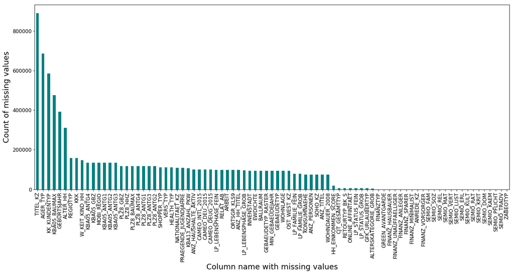

```python
# Visualizing the NaN data in the mapped azdias dataset.
azdias.isnull().sum().sort_values(ascending=False).plot.bar(figsize=(20,8),fontsize=12,color='teal');
plt.xlabel('Column name with missing values', fontsize=18)
plt.ylabel('Count of missing values', fontsize=18)
plt.show()
```

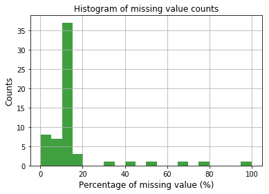

```python
#Plot distribution of missing value counts in columns
plt.hist(azdias_after_nan['pct'], bins=20, facecolor='g', alpha=0.75)


plt.xlabel('Percentage of missing value (%)', fontsize=12)
plt.ylabel('Counts', fontsize=12)
plt.title('Histogram of missing value counts', fontsize=12)
plt.grid(True)
plt.show()
```

We can see that columns with more than 20% missing values are outliers in the histogram above. Here, we will investigate those columns and decide if it is OK to drop them from the data frame. But first let’s see a bar plot of all columns with missing values and their percentage.

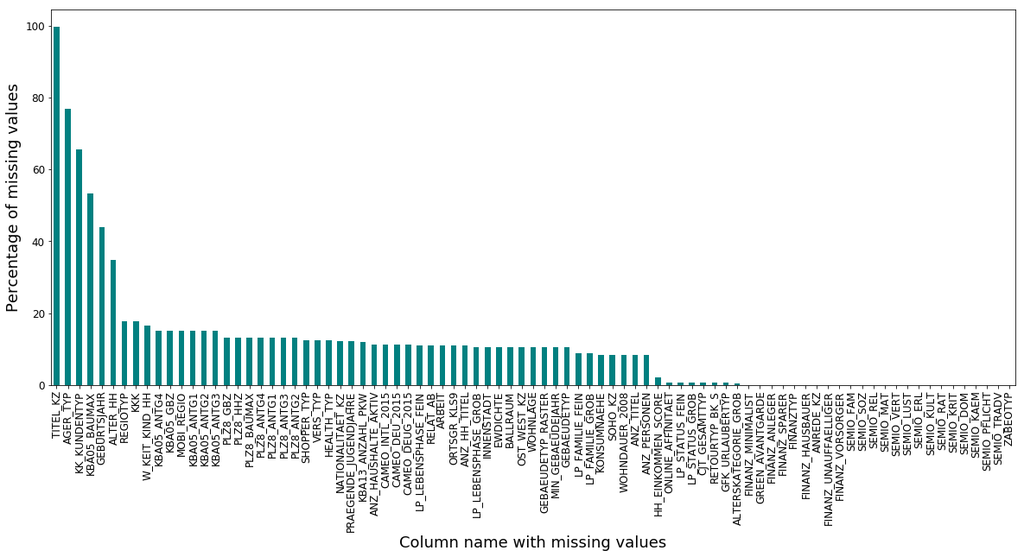

```python
# Visualizing the percentage of NaN data in the mapped azdias dataset.
np.round(azdias.isnull().sum()*100/azdias.shape[0],2).sort_values(ascending=False).plot.bar(figsize=(20,8),fontsize=12,color='teal');
plt.xlabel('Column name with missing values', fontsize=18)
plt.ylabel('Percentage of missing values', fontsize=18)
plt.show()
```

Looking at the distribution of missing value counts(in the histogram above) and the bar plot(Percentage of missing values vs Column name with missing values) above, we can see that there are 61 columns with missing values ranging from 0.32% to 99.76%. Out of 61 columns(having missing values), 55 columns have less than 20% of the missing values and 6 columns have more than 20% of missing values. So, we can say, that out of 85 columns(which includes 61 columns with missing values and 24 columns with no missing values), 79 columns have less than 20% of the missing values and 6 columns have more than 20% of the misisng values.

```python
# Investigate patterns in the amount of missing data in each column.

index_groupby_info_level = {}
for info_level in feat_info['information_level'].unique():
    index_groupby_info_level[info_level] = feat_info[feat_info['information_level'] == info_level].index.values

index_groupby_info_level
```

```
{'person': array(['AGER_TYP', 'ALTERSKATEGORIE_GROB', 'ANREDE_KZ', 'CJT_GESAMTTYP',
        'FINANZ_MINIMALIST', 'FINANZ_SPARER', 'FINANZ_VORSORGER',
        'FINANZ_ANLEGER', 'FINANZ_UNAUFFAELLIGER', 'FINANZ_HAUSBAUER',
        'FINANZTYP', 'GEBURTSJAHR', 'GFK_URLAUBERTYP', 'GREEN_AVANTGARDE',
        'HEALTH_TYP', 'LP_LEBENSPHASE_FEIN', 'LP_LEBENSPHASE_GROB',
        'LP_FAMILIE_FEIN', 'LP_FAMILIE_GROB', 'LP_STATUS_FEIN',
        'LP_STATUS_GROB', 'NATIONALITAET_KZ', 'PRAEGENDE_JUGENDJAHRE',
        'RETOURTYP_BK_S', 'SEMIO_SOZ', 'SEMIO_FAM', 'SEMIO_REL',
        'SEMIO_MAT', 'SEMIO_VERT', 'SEMIO_LUST', 'SEMIO_ERL', 'SEMIO_KULT',
        'SEMIO_RAT', 'SEMIO_KRIT', 'SEMIO_DOM', 'SEMIO_KAEM',
        'SEMIO_PFLICHT', 'SEMIO_TRADV', 'SHOPPER_TYP', 'SOHO_KZ',
        'TITEL_KZ', 'VERS_TYP', 'ZABEOTYP'], dtype=object),
 'household': array(['ALTER_HH', 'ANZ_PERSONEN', 'ANZ_TITEL', 'HH_EINKOMMEN_SCORE',
        'KK_KUNDENTYP', 'W_KEIT_KIND_HH', 'WOHNDAUER_2008'], dtype=object),
 'building': array(['ANZ_HAUSHALTE_AKTIV', 'ANZ_HH_TITEL', 'GEBAEUDETYP', 'KONSUMNAEHE',
        'MIN_GEBAEUDEJAHR', 'OST_WEST_KZ', 'WOHNLAGE'], dtype=object),
 'microcell_rr4': array(['CAMEO_DEUG_2015', 'CAMEO_DEU_2015', 'CAMEO_INTL_2015'], dtype=object),
 'microcell_rr3': array(['KBA05_ANTG1', 'KBA05_ANTG2', 'KBA05_ANTG3', 'KBA05_ANTG4',
        'KBA05_BAUMAX', 'KBA05_GBZ'], dtype=object),
 'postcode': array(['BALLRAUM', 'EWDICHTE', 'INNENSTADT'], dtype=object),
 'region_rr1': array(['GEBAEUDETYP_RASTER', 'KKK', 'MOBI_REGIO', 'ONLINE_AFFINITAET',
        'REGIOTYP'], dtype=object),
 'macrocell_plz8': array(['KBA13_ANZAHL_PKW', 'PLZ8_ANTG1', 'PLZ8_ANTG2', 'PLZ8_ANTG3',
        'PLZ8_ANTG4', 'PLZ8_BAUMAX', 'PLZ8_HHZ', 'PLZ8_GBZ'], dtype=object),
 'community': array(['ARBEIT', 'ORTSGR_KLS9', 'RELAT_AB'], dtype=object)}
```

```python
index_groupby_info_level.keys()
```

```
dict_keys(['person', 'household', 'building', 'microcell_rr4', 'microcell_rr3', 'postcode', 'region_rr1', 'macrocell_plz8', 'community'])
```

```python
index_groupby_info_level['person']
```

```
array(['AGER_TYP', 'ALTERSKATEGORIE_GROB', 'ANREDE_KZ', 'CJT_GESAMTTYP',
       'FINANZ_MINIMALIST', 'FINANZ_SPARER', 'FINANZ_VORSORGER',
       'FINANZ_ANLEGER', 'FINANZ_UNAUFFAELLIGER', 'FINANZ_HAUSBAUER',
       'FINANZTYP', 'GEBURTSJAHR', 'GFK_URLAUBERTYP', 'GREEN_AVANTGARDE',
       'HEALTH_TYP', 'LP_LEBENSPHASE_FEIN', 'LP_LEBENSPHASE_GROB',
       'LP_FAMILIE_FEIN', 'LP_FAMILIE_GROB', 'LP_STATUS_FEIN',
       'LP_STATUS_GROB', 'NATIONALITAET_KZ', 'PRAEGENDE_JUGENDJAHRE',
       'RETOURTYP_BK_S', 'SEMIO_SOZ', 'SEMIO_FAM', 'SEMIO_REL',
       'SEMIO_MAT', 'SEMIO_VERT', 'SEMIO_LUST', 'SEMIO_ERL', 'SEMIO_KULT',
       'SEMIO_RAT', 'SEMIO_KRIT', 'SEMIO_DOM', 'SEMIO_KAEM',
       'SEMIO_PFLICHT', 'SEMIO_TRADV', 'SHOPPER_TYP', 'SOHO_KZ',
       'TITEL_KZ', 'VERS_TYP', 'ZABEOTYP'], dtype=object)
```

```python
index_groupby_info_level['person'][0]
```

```
'AGER_TYP'
```

```python
index_groupby_info_level['person'][-1]
```

```
'ZABEOTYP'
```

```python
azdias.loc[:, index_groupby_info_level['person'][0]:index_groupby_info_level['person'][-1]].head()
```

|  | AGER_TYP | ALTERSKATEGORIE_GROB | ANREDE_KZ | CJT_GESAMTTYP | FINANZ_MINIMALIST | FINANZ_SPARER | FINANZ_VORSORGER | FINANZ_ANLEGER | FINANZ_UNAUFFAELLIGER | FINANZ_HAUSBAUER | ... | SEMIO_KRIT | SEMIO_DOM | SEMIO_KAEM | SEMIO_PFLICHT | SEMIO_TRADV | SHOPPER_TYP | SOHO_KZ | TITEL_KZ | VERS_TYP | ZABEOTYP |
| --- | --- | --- | --- | --- | --- | --- | --- | --- | --- | --- | --- | --- | --- | --- | --- | --- | --- | --- | --- | --- | --- |
| 0 | NaN | 2.0 | 1 | 2.0 | 3 | 4 | 3 | 5 | 5 | 3 | ... | 7 | 6 | 6 | 5 | 3 | NaN | NaN | NaN | NaN | 3 |
| 1 | NaN | 1.0 | 2 | 5.0 | 1 | 5 | 2 | 5 | 4 | 5 | ... | 4 | 7 | 4 | 7 | 6 | 3.0 | 1.0 | NaN | 2.0 | 5 |
| 2 | NaN | 3.0 | 2 | 3.0 | 1 | 4 | 1 | 2 | 3 | 5 | ... | 7 | 7 | 7 | 3 | 3 | 2.0 | 0.0 | NaN | 1.0 | 5 |
| 3 | 2.0 | 4.0 | 2 | 2.0 | 4 | 2 | 5 | 2 | 1 | 2 | ... | 4 | 4 | 5 | 4 | 4 | 1.0 | 0.0 | NaN | 1.0 | 3 |
| 4 | NaN | 3.0 | 1 | 5.0 | 4 | 3 | 4 | 1 | 3 | 2 | ... | 3 | 2 | 2 | 4 | 2 | 2.0 | 0.0 | NaN | 2.0 | 4 |

5 rows × 43 columns

```python
azdias['KK_KUNDENTYP'].isnull().sum()
```

```
584612
```

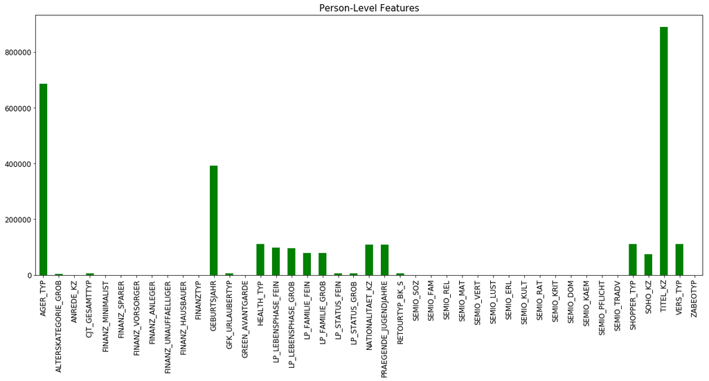

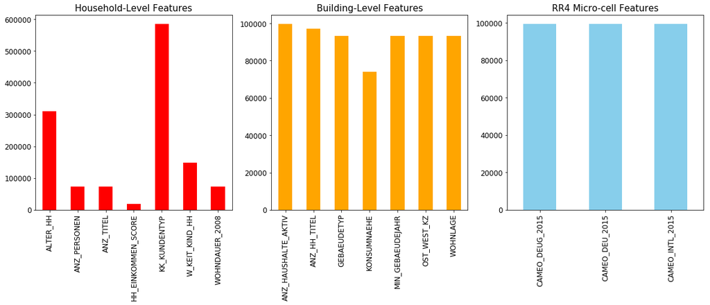

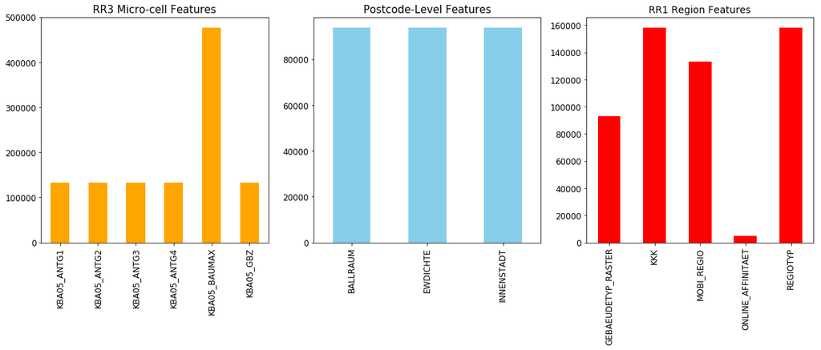

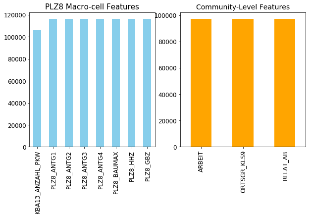

```python
# Visualize the missing data by each data group i.e. by feature level.

plt.figure(1,figsize=(20,8))

plt.subplot(111)
azdias.loc[:, index_groupby_info_level['person'][0]:index_groupby_info_level['person'][-1]]\
.isnull().sum().plot.bar(fontsize=12,color='green')
plt.title('Person-Level Features',fontsize=15)

plt.figure(2,figsize=(20,6))

plt.subplot(131)
azdias.loc[:, index_groupby_info_level['household'][0]:index_groupby_info_level['household'][-1]]\
.isnull().sum().plot.bar(fontsize=12,color='red')
plt.title('Household-Level Features',fontsize=15)

plt.subplot(132)
azdias.loc[:, index_groupby_info_level['building'][0]:index_groupby_info_level['building'][-1]]\
.isnull().sum().plot.bar(fontsize=12,color='orange')
plt.title('Building-Level Features',fontsize=15)

plt.subplot(133)
azdias.loc[:, index_groupby_info_level['microcell_rr4'][0]:index_groupby_info_level['microcell_rr4'][-1]]\
.isnull().sum().plot.bar(fontsize=12,color='skyblue')
plt.title('RR4 Micro-cell Features',fontsize=15)


plt.figure(3,figsize=(20,6))

plt.subplot(131)
azdias.loc[:, index_groupby_info_level['microcell_rr3'][0]:index_groupby_info_level['microcell_rr3'][-1]]\
.isnull().sum().plot.bar(fontsize=12,color='orange')
plt.title('RR3 Micro-cell Features',fontsize=15)

plt.subplot(132)
azdias.loc[:, index_groupby_info_level['postcode'][0]:index_groupby_info_level['postcode'][-1]]\
.isnull().sum().plot.bar(fontsize=12,color='skyblue')
plt.title('Postcode-Level Features',fontsize=15)


plt.subplot(133)
azdias.loc[:, index_groupby_info_level['region_rr1'][0]:index_groupby_info_level['region_rr1'][-1]]\
.isnull().sum().plot.bar(fontsize=12,color='red')
plt.title('RR1 Region Features',fontsize=14)


plt.figure(4,figsize=(10,5))
plt.subplot(121)
azdias.loc[:, index_groupby_info_level['macrocell_plz8'][0]:index_groupby_info_level['macrocell_plz8'][-1]]\
.isnull().sum().plot.bar(fontsize=12,color='skyblue')
plt.title('PLZ8 Macro-cell Features',fontsize=15)

plt.subplot(122)
azdias.loc[:, index_groupby_info_level['community'][0]:index_groupby_info_level['community'][-1]]\
.isnull().sum().plot.bar(fontsize=12,color='orange')
plt.title('Community-Level Features',fontsize=14)

plt.show()
```

```python
# Find the name of columns with more than 20% missing values
missing_20 = [col for col in azdias.columns if (azdias[col].isnull().sum()/azdias.shape[0]) * 100 > 20]
print(missing_20)
```

```
['AGER_TYP', 'GEBURTSJAHR', 'TITEL_KZ', 'ALTER_HH', 'KK_KUNDENTYP', 'KBA05_BAUMAX']
```

```python
# Remove the outlier columns from the dataset. (You'll perform other data
# engineering tasks such as re-encoding and imputation later.)

for col in missing_20:
    azdias.drop(col, axis=1, inplace=True)
```

```python
# Shape of azdias after removing outliers columns
azdias.shape
```

```
(891221, 79)
```

#### Discussion 1.1.2: Assess Missing Data in Each Column

- From the above graphs and plots, we can see 6 columns clearly stand out, with more than 20% of missing observations namely 'AGER_TYP', 'GEBURTSJAHR', 'TITEL_KZ', 'ALTER_HH', 'KK_KUNDENTYP' and 'KBA05_BAUMAX'.

Looking at each of the columns individually to determine their significance -

- 'KK_KUNDENTYP' fetaure has the greatest number of observations missing i.e. 584,612 observations or 66% observations are missing. This category relates to consumer pattern over past 12 months, so the presumption is that missing observations are people from the population who are not a customer of the mail order company in the last 12 months. This column can de dropped from the dataset as the information is not useful in obtaining customer segments from the population. This information is part of the customer dataset. Decision drop "KK_Kundentyp".
- 'TITEL_KZ' relates to an academic title and with 99.76% missing observations, therefore droppping the column.
- 'AGER_TYP' relates to a split in elderly persons, this information is partially found in other categories and can be also safely dropped without losing value.
- 'KBA05_BAUMAX' is kind of summary of related features 'KBA05_ANTG1', 'KBA05_ANTG2', 'KBA05_ANTG3', 'KBA05_ANTG4' and so can be safely dropped.
- 'GEBURTSJAHR' relates to year of birth, since this information is genaralized in other person-level categories and with 44% of the information missing, imputing wouldn't make sense so it is better to drop this column also.
- Lastly 'ALTER_HH' is again related to the date of birth of the head of the household and can be dropped for the same reasons as 'GEBURTSJAHR'.

Therefore, taking the decision to drop the 6 outlier columns namely 'TITEL_KZ', 'AGER_TYP', 'KK_KUDENTYP', 'KBA05_BAUMAX', 'GEBURTSJAHR' and 'ALTER_HH'.

#### Step 1.1.3: Assess Missing Data in Each Row

Now, you'll perform a similar assessment for the rows of the dataset. How much data is missing in each row? As with the columns, you should see some groups of points that have a very different numbers of missing values. Divide the data into two subsets: one for data points that are above some threshold for missing values, and a second subset for points below that threshold.

In order to know what to do with the outlier rows, we should see if the distribution of data values on columns that are not missing data (or are missing very little data) are similar or different between the two groups. Select at least five of these columns and compare the distribution of values.

- You can use seaborn's [`countplot()`](https://seaborn.pydata.org/generated/seaborn.countplot.html) function to create a bar chart of code frequencies and matplotlib's [`subplot()`](https://matplotlib.org/api/_as_gen/matplotlib.pyplot.subplot.html) function to put bar charts for the two subplots side by side.
- To reduce repeated code, you might want to write a function that can perform this comparison, taking as one of its arguments a column to be compared.

Depending on what you observe in your comparison, this will have implications on how you approach your conclusions later in the analysis. If the distributions of non-missing features look similar between the data with many missing values and the data with few or no missing values, then we could argue that simply dropping those points from the analysis won't present a major issue. On the other hand, if the data with many missing values looks very different from the data with few or no missing values, then we should make a note on those data as special. We'll revisit these data later on. **Either way, you should continue your analysis for now using just the subset of the data with few or no missing values.**

```python
# How much data is missing in each row of the dataset?

azdias_null_data_row = azdias.isnull().sum(axis=1)

# Aggregate missing row data by number of missing values per row
print('Below are the number of missing values in a row along with their frequencies')
azdias_null_data_row.value_counts().sort_index()
```

```
Below are the number of missing values in a row along with their frequencies
```

```
0     623209
1      15738
2      27926
3      17629
4      12607
5      22515
6      13771
7      13714
8      24592
9       3042
10      5410
11      1127
12       766
13      3255
14      2243
```

[output cut: 35 more lines]

```python
a = azdias_null_data_row/(len(azdias.columns)) * 100
a.sort_values(inplace=True)
a.value_counts().sort_index()
```

```
0.000000     623209
1.265823      15738
2.531646      27926
3.797468      17629
5.063291      12607
6.329114      22515
7.594937      13771
8.860759      13714
10.126582     24592
11.392405      3042
12.658228      5410
13.924051      1127
15.189873       766
16.455696      3255
17.721519      2243
18.987342      4743
20.253165      2505
21.518987       677
22.784810       428
24.050633      1180
25.316456       349
26.582278       150
27.848101       129
29.113924       132
30.379747        69
31.645570        55
32.911392        59
34.177215        24
35.443038         5
36.708861        12
37.974684         6
39.240506         3
40.506329       206
41.772152      2985
43.037975     10816
44.303797      3911
45.569620        84
46.835443       538
48.101266       421
49.367089        77
50.632911       137
51.898734       356
53.164557        21
54.430380     27369
55.696203       155
56.962025       494
59.493671     45578
60.759494         1
62.025316         2
dtype: int64
```

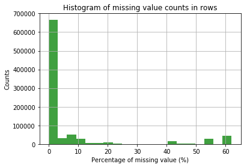

```python
# Plot distribution of missing value counts in rows.

azdias_null_data_row_percentage = azdias_null_data_row/(len(azdias.columns)) * 100
azdias_null_data_row_percentage.sort_values(inplace=True)

plt.hist(azdias_null_data_row_percentage, bins=20, facecolor='g', alpha=0.75)

plt.xlabel('Percentage of missing value (%)')
plt.ylabel('Counts')
plt.title('Histogram of missing value counts in rows')
plt.grid(True)
plt.show()
```

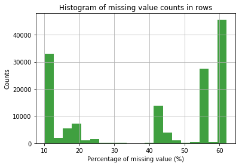

```python
# Zooming in the histogram and ploting the distribution of rows with atleast 10% missing data.

plt.hist(azdias_null_data_row_percentage[azdias_null_data_row_percentage >= 10], bins=20, facecolor='g', alpha=0.75)
plt.xlabel('Percentage of missing value (%)')
plt.ylabel('Counts')
plt.title('Histogram of missing value counts in rows')
plt.grid(True)
plt.show()
```

```python
# Calculate count and percentage of rows with no missing data points

print('Count of rows with no missing data points: {}'\
      .format(np.round(azdias_null_data_row.value_counts().sort_index().cumsum()[0])))
print('Total number of rows in the dataset : {}'.format(azdias.shape[0]))
print('Percentage of rows with no missing data points: {}%'\
      .format(np.round(azdias_null_data_row.value_counts().sort_index().cumsum()[0]/azdias.shape[0] *100,2)))
```

```
Count of rows with no missing data points: 623209
Total number of rows in the dataset : 891221
Percentage of rows with no missing data points: 69.93%
```

```python
# Calculate cumulative sum of rows with 32 or less missing data points
cumsum= azdias_null_data_row.value_counts().sort_index().cumsum()[:32]
print('Cumulative sums of rows with 32 or less missing data points are : \n{}'.format(cumsum))
cumsum_percentage = np.round(azdias_null_data_row.value_counts().sort_index().cumsum()[:32]/azdias_null_data_row.shape[0]*100,2)
print('\nCumulative percentage of rows with 32 or less missing data points are : \n{}'.format(cumsum_percentage))
```

```
Cumulative sums of rows with 32 or less missing data points are :
0     623209
1     638947
2     666873
3     684502
4     697109
5     719624
6     733395
7     747109
8     771701
9     774743
10    780153
11    781280
12    782046
13    785301
```

[output cut: 54 more lines]

```python
# Calculate percentage of rows with 8 or less missing data points

print('Count of rows with 8 or less missing data points: {}'.format(cumsum[8]))
print('Total number of rows in the dataset : {}'.format(azdias.shape[0]))
print("Percentage of rows with 8 or less missing data points:",cumsum_percentage[8],"%")
```

```
Count of rows with 8 or less missing data points: 771701
Total number of rows in the dataset : 891221
Percentage of rows with 8 or less missing data points: 86.59 %
```

```python
# Write code to divide the data into two subsets based on the number of missing
# values to be 8 or less in each row.

azdias_null_data_row_few = azdias[azdias.isnull().sum(axis=1) < 9].reset_index(drop=True)

azdias_null_data_row_high = azdias[azdias.isnull().sum(axis=1) >= 9].reset_index(drop=True)
```

```python
# Printing the number of rows with few missing data and high missing data.
print('Number of rows with few missing data : {}'.format(azdias_null_data_row_few.shape[0]))
print('Number of rows with high missing data : {}'.format(azdias_null_data_row_high.shape[0]))

# Checking if the number of rows with few missing data and high missing data adds upto total number of rows in azdias dataset.
if azdias.shape[0] == azdias_null_data_row_few.shape[0] + azdias_null_data_row_high.shape[0]:
    print('Number of rows with few missing data and high missing data adds upto total number of rows in azdias dataset,\
 which is : {}'.format(azdias_null_data_row_few.shape[0] + azdias_null_data_row_high.shape[0]))
else:
    print('Number of total rows in few missing dataset and high missing dataset is not equal\
    to the total number of rows in the dataset')
```

```
Number of rows with few missing data : 771701
Number of rows with high missing data : 119520
Number of rows with few missing data and high missing data adds upto total number of rows in azdias dataset, which is : 891221
```

```python
# Printing columns with no or 2 missing values in columns of azdias dataset with outliers columns removed.

azdias_no_null_columns = azdias.isnull().sum() < 2
#print(azdias_no_null_columns.shape)
#print(azdias_no_null_columns.sort_values())
#print(azdias_no_null_columns[azdias_no_null_columns.values == True])
#print(azdias_no_null_columns[azdias_no_null_columns.values == True].shape)
print('Below are the columns of azdias dataset(outliers removed azdias dataset) with no nulls or 2 missing values\n')
print(azdias_no_null_columns[azdias_no_null_columns.values == True].index)
```

```
Below are the columns of azdias dataset(outliers removed azdias dataset) with no nulls or 2 missing values

Index(['ANREDE_KZ', 'FINANZ_MINIMALIST', 'FINANZ_SPARER', 'FINANZ_VORSORGER',
       'FINANZ_ANLEGER', 'FINANZ_UNAUFFAELLIGER', 'FINANZ_HAUSBAUER',
       'FINANZTYP', 'GREEN_AVANTGARDE', 'SEMIO_SOZ', 'SEMIO_FAM', 'SEMIO_REL',
       'SEMIO_MAT', 'SEMIO_VERT', 'SEMIO_LUST', 'SEMIO_ERL', 'SEMIO_KULT',
       'SEMIO_RAT', 'SEMIO_KRIT', 'SEMIO_DOM', 'SEMIO_KAEM', 'SEMIO_PFLICHT',
       'SEMIO_TRADV', 'ZABEOTYP'],
      dtype='object')
```

```
Randomly selected columns names with no or 2 missing values are :
['SEMIO_LUST', 'SEMIO_DOM', 'SEMIO_REL', 'GREEN_AVANTGARDE', 'FINANZ_ANLEGER', 'FINANZ_UNAUFFAELLIGER', 'ANREDE_KZ']
```

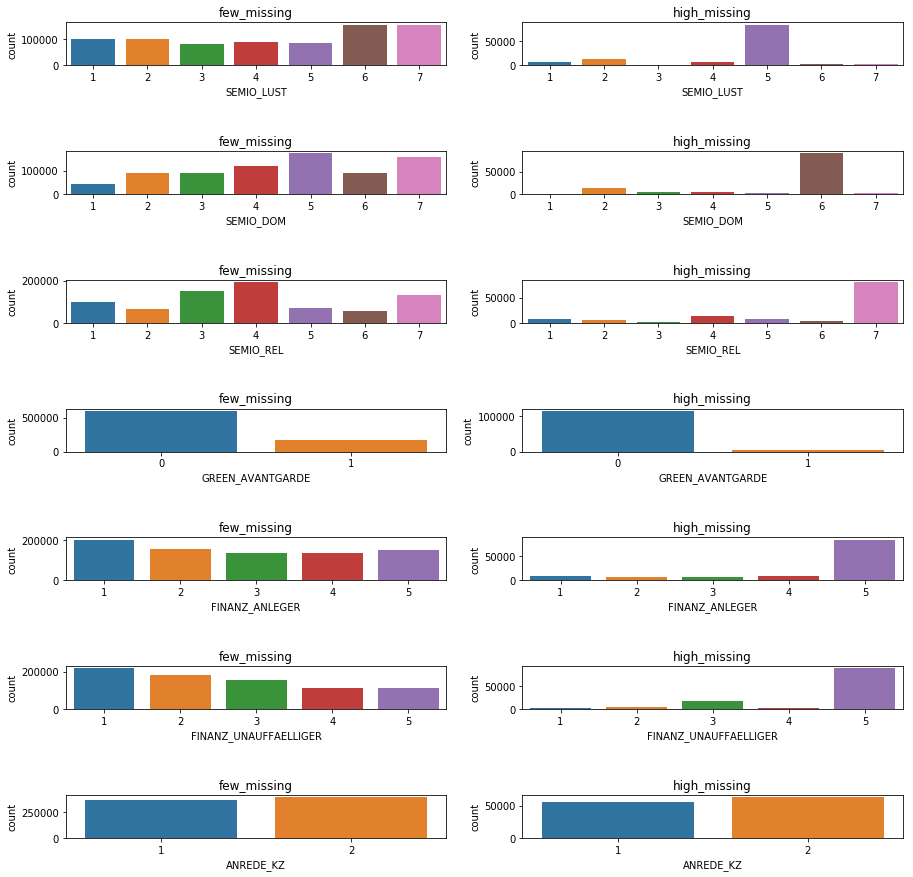

```python
# Compare the distribution of values for at least five columns where there are
# no or few missing values, between the two subsets.

col_names_no_null = list(azdias_no_null_columns[azdias_no_null_columns.values == True].index)

# Selecting random sample from the list of columns with no null values.
random.seed(9)
random_cols = random.sample(col_names_no_null, 7)
print('Randomly selected columns names with no or 2 missing values are : \n{}'.format(random_cols))

def print_countplot(cols, num):

    fig, axs = plt.subplots(num,2, figsize=(15, 15), facecolor='w', edgecolor='k')
    fig.subplots_adjust(hspace =2 , wspace=.2)
    axs = axs.ravel()

    for i in range(num):

        sns.countplot(azdias_null_data_row_few[cols[i]], ax=axs[i*2])
        axs[i*2].set_title('few_missing')

        sns.countplot(azdias_null_data_row_high[cols[i]], ax=axs[i*2+1])
        axs[i*2+1].set_title('high_missing')


print_countplot(random_cols, 7)
```

```python
# Drop rows with high missing values in the azdias dataset.

print('Total number of rows : {}'.format(azdias.shape[0]))

azdias = azdias[azdias.index.isin(azdias_null_data_row_few.index)]

print('Number of rows after dropping rows with more than 8 missing values : {}'.format(azdias.shape[0]))
```

```
Total number of rows : 891221
Number of rows after dropping rows with more than 8 missing values : 771701
```

#### Discussion 1.1.3: Assess Missing Data in Each Row

First of all, we can see 623,209 rows are complete out of a total of 891,221 or 69.93% of the total dataset is complete.

Clearly we can see from the above histograms that most of our data comprises of rows with no missing values(69.93%).Therefore, about 70% of our dataset is complete. Also, we can see that there appears to be a group with more than 40% of the missing data in rows making them as outliers. Specially rows with 34(43.03%), 43(54.43%) and 47(59.49%) missing values contribute heavily to this and can be considered outliers. The total number of rows of rows with these 3 missing values are 83,763 and comprises 9.39% of total rows. Therefore, the reliability and usefulness of rows with 34, 43 and 47 missing values is limited. So, rows with more than 40% misisng values in a row can be considered as outliers.

If we compare the distribution of 7 random selected features or columns that are missing less than 2 data values in these 2 subsets(One with 8 or less missing values & other with more than 8 missing values) as can be seen from the above bar charts, we could see that the distribution of columns data within subset of few missing values is qualitatively different from the columns data within subset of many missing values. We can see features 'GREEN_AVANTGARDE' & 'ANREDE_KZ' seems comparable and other features namely 'SEMIO_LUST', 'SEMIO_DOM', 'SEMIO_REL', 'FINANZ_ANLEGER' & 'FINANZ_UNAUFFAELLIGER' are highly different in distribution. 'GREEN_AVANTGARDE' is membership in environmental sustainability and 'ANREDE_KZ' is gender. Member of Green Avantgarde column is similarly distributed, with both populations not being a member of Green Avantgarde. Also, the gender column is similarly distributed, with both populations being mostly female.

Considering that the clustering algorithm K-means requires no missing information to work and that the dataset is made up of mainly ordinal and categorical data, where imputing values with means, modes or medians can impact the truth of the dataset much more than if the dataset was made up of numerical data. Therefore, it seems more appropriate to minimize imputing missing data and maintain the integrity at maximum. Therfore, we would minimize imputing missing values to 8 missing values in a row.

We could also have discarded all rows with any missing values and kept 70% of the complete dataset and performed no imputation. In a real-world scenario, we would have discarded all rows with any missing observations, but since we are doing this course to learn, therefore, we would keep rows with 8 or less missing values and do all the steps and practice everything.

### Step 1.2: Select and Re-Encode Features

Checking for missing data isn't the only way in which you can prepare a dataset for analysis. Since the unsupervised learning techniques to be used will only work on data that is encoded numerically, you need to make a few encoding changes or additional assumptions to be able to make progress. In addition, while almost all of the values in the dataset are encoded using numbers, not all of them represent numeric values. Check the third column of the feature summary (`feat_info`) for a summary of types of measurement.

- For numeric and interval data, these features can be kept without changes.
- Most of the variables in the dataset are ordinal in nature. While ordinal values may technically be non-linear in spacing, make the simplifying assumption that the ordinal variables can be treated as being interval in nature (that is, kept without any changes).
- Special handling may be necessary for the remaining two variable types: categorical, and 'mixed'.

In the first two parts of this sub-step, you will perform an investigation of the categorical and mixed-type features and make a decision on each of them, whether you will keep, drop, or re-encode each. Then, in the last part, you will create a new data frame with only the selected and engineered columns.

Data wrangling is often the trickiest part of the data analysis process, and there's a lot of it to be done here. But stick with it: once you're done with this step, you'll be ready to get to the machine learning parts of the project!

```python
azdias.columns
```

```
Index(['ALTERSKATEGORIE_GROB', 'ANREDE_KZ', 'CJT_GESAMTTYP',
       'FINANZ_MINIMALIST', 'FINANZ_SPARER', 'FINANZ_VORSORGER',
       'FINANZ_ANLEGER', 'FINANZ_UNAUFFAELLIGER', 'FINANZ_HAUSBAUER',
       'FINANZTYP', 'GFK_URLAUBERTYP', 'GREEN_AVANTGARDE', 'HEALTH_TYP',
       'LP_LEBENSPHASE_FEIN', 'LP_LEBENSPHASE_GROB', 'LP_FAMILIE_FEIN',
       'LP_FAMILIE_GROB', 'LP_STATUS_FEIN', 'LP_STATUS_GROB',
       'NATIONALITAET_KZ', 'PRAEGENDE_JUGENDJAHRE', 'RETOURTYP_BK_S',
       'SEMIO_SOZ', 'SEMIO_FAM', 'SEMIO_REL', 'SEMIO_MAT', 'SEMIO_VERT',
       'SEMIO_LUST', 'SEMIO_ERL', 'SEMIO_KULT', 'SEMIO_RAT', 'SEMIO_KRIT',
       'SEMIO_DOM', 'SEMIO_KAEM', 'SEMIO_PFLICHT', 'SEMIO_TRADV',
       'SHOPPER_TYP', 'SOHO_KZ', 'VERS_TYP', 'ZABEOTYP', 'ANZ_PERSONEN',
       'ANZ_TITEL', 'HH_EINKOMMEN_SCORE', 'W_KEIT_KIND_HH', 'WOHNDAUER_2008',
       'ANZ_HAUSHALTE_AKTIV', 'ANZ_HH_TITEL', 'GEBAEUDETYP', 'KONSUMNAEHE',
       'MIN_GEBAEUDEJAHR', 'OST_WEST_KZ', 'WOHNLAGE', 'CAMEO_DEUG_2015',
       'CAMEO_DEU_2015', 'CAMEO_INTL_2015', 'KBA05_ANTG1', 'KBA05_ANTG2',
       'KBA05_ANTG3', 'KBA05_ANTG4', 'KBA05_GBZ', 'BALLRAUM', 'EWDICHTE',
       'INNENSTADT', 'GEBAEUDETYP_RASTER', 'KKK', 'MOBI_REGIO',
       'ONLINE_AFFINITAET', 'REGIOTYP', 'KBA13_ANZAHL_PKW', 'PLZ8_ANTG1',
       'PLZ8_ANTG2', 'PLZ8_ANTG3', 'PLZ8_ANTG4', 'PLZ8_BAUMAX', 'PLZ8_HHZ',
       'PLZ8_GBZ', 'ARBEIT', 'ORTSGR_KLS9', 'RELAT_AB'],
      dtype='object')
```

```python
len(azdias.columns)
```

```
79
```

```python
# How many features are there of each data type?
d={}
for col in azdias.columns:
    data_type = feat_info.loc[col].type
    if data_type not in d:
        d[data_type] = 1
    else:
        d[data_type] += 1

print('Nunber of features of each data type are : {}'.format(d))
```

```
Nunber of features of each data type are : {'ordinal': 49, 'categorical': 18, 'mixed': 6, 'numeric': 6}
```

#### Step 1.2.1: Re-Encode Categorical Features

For categorical data, you would ordinarily need to encode the levels as dummy variables. Depending on the number of categories, perform one of the following:

- For binary (two-level) categoricals that take numeric values, you can keep them without needing to do anything.
- There is one binary variable that takes on non-numeric values. For this one, you need to re-encode the values as numbers or create a dummy variable.
- For multi-level categoricals (three or more values), you can choose to encode the values using multiple dummy variables (e.g. via [OneHotEncoder](http://scikit-learn.org/stable/modules/generated/sklearn.preprocessing.OneHotEncoder.html)), or (to keep things straightforward) just drop them from the analysis. As always, document your choices in the Discussion section.

```python
# Assess categorical variables: which are binary, which are multi-level, and
# which one needs to be re-encoded?

#extract categorical columns with their data types and number of categories
bin_cat = []
multi_cat = []
for col in azdias.columns:
    if feat_info.loc[col].type == 'categorical':
        if len(azdias[col].value_counts()) == 2:
            bin_cat.append(col)
        else:
            multi_cat.append(col)
        print(col, len(azdias[col].value_counts()), azdias[col].dtype)
print('\nBinary categorical variables are : {}'.format(bin_cat))
print('\nMulti-level categorical variables are : {}'.format(multi_cat))
```

```
ANREDE_KZ 2 int64
CJT_GESAMTTYP 6 float64
FINANZTYP 6 int64
GFK_URLAUBERTYP 12 float64
GREEN_AVANTGARDE 2 int64
LP_FAMILIE_FEIN 11 float64
LP_FAMILIE_GROB 5 float64
LP_STATUS_FEIN 10 float64
LP_STATUS_GROB 5 float64
NATIONALITAET_KZ 3 float64
SHOPPER_TYP 4 float64
SOHO_KZ 2 float64
VERS_TYP 2 float64
ZABEOTYP 6 int64
GEBAEUDETYP 6 float64
OST_WEST_KZ 2 object
CAMEO_DEUG_2015 9 object
CAMEO_DEU_2015 44 object

Binary categorical variables are : ['ANREDE_KZ', 'GREEN_AVANTGARDE', 'SOHO_KZ', 'VERS_TYP', 'OST_WEST_KZ']

Multi-level categorical variables are : ['CJT_GESAMTTYP', 'FINANZTYP', 'GFK_URLAUBERTYP', 'LP_FAMILIE_FEIN', 'LP_FAMILIE_GROB', 'LP_STATUS_FEIN', 'LP_STATUS_GROB', 'NATIONALITAET_KZ', 'SHOPPER_TYP', 'ZABEOTYP', 'GEBAEUDETYP', 'CAMEO_DEUG_2015', 'CAMEO_DEU_2015']
```

```python
# Find the column names for mixed type columns
mixed_features = []
for col in azdias.columns:
    if feat_info.loc[col].type == 'mixed':
        mixed_features.append(col)

print('\nMixed type variables are : {}'.format(mixed_features))
```

```
Mixed type variables are : ['LP_LEBENSPHASE_FEIN', 'LP_LEBENSPHASE_GROB', 'PRAEGENDE_JUGENDJAHRE', 'WOHNLAGE', 'CAMEO_INTL_2015', 'PLZ8_BAUMAX']
```

```python
# Printing out binary categorical values

for col in bin_cat:
    print(azdias[col].value_counts())
```

```
2    403130
1    368571
Name: ANREDE_KZ, dtype: int64
0    619386
1    152315
Name: GREEN_AVANTGARDE, dtype: int64
0.0    702635
1.0      5922
Name: SOHO_KZ, dtype: int64
2.0    345664
1.0    330182
Name: VERS_TYP, dtype: int64
W    547127
O    144376
Name: OST_WEST_KZ, dtype: int64
```

There are 5 binary features, out of which 'ANREDE_KZ', 'GREEN_AVANTGARDE', 'SOHO_KZ', 'VERS_TYP' take numeric values, so we don't need to do anything with them. One feature 'OST_WEST_KZ' take non-numeric values, therefore, we will re-encode the values as numbers.

```python
# Re-encode categorical variable(s) to be kept in the analysis.

# Change 'OST_WEST_KZ' into numerical values
azdias['OST_WEST_KZ'].replace(['W','O'], [1, 0], inplace=True)
```

```python
azdias['OST_WEST_KZ'].value_counts()
```

```
1.0    547127
0.0    144376
Name: OST_WEST_KZ, dtype: int64
```

```python
# Printing out binary categorical values after feature 'OST_WEST_KZ' has been re-encoded to numerical values
for col in bin_cat:
    print(azdias[col].value_counts())
```

```
2    403130
1    368571
Name: ANREDE_KZ, dtype: int64
0    619386
1    152315
Name: GREEN_AVANTGARDE, dtype: int64
0.0    702635
1.0      5922
Name: SOHO_KZ, dtype: int64
2.0    345664
1.0    330182
Name: VERS_TYP, dtype: int64
1.0    547127
0.0    144376
Name: OST_WEST_KZ, dtype: int64
```

```python
# OneHotEncoding multi-level categoricals (three or more values), using multiple dummy variables via OneHotEncoder.

azdias = pd.get_dummies(azdias, columns=multi_cat, prefix=multi_cat)
```

```python
# Shape of azdias dataset after oneHotEncoding multi-level categorical variables.

azdias.shape
```

```
(771701, 193)
```

#### Discussion 1.2.1: Re-Encode Categorical Features

18 Categorical features or columns were categorized between binary variables having 2 values and multiple variables having 3 or more values. There were 5 binary features, out of which 'ANREDE_KZ', 'GREEN_AVANTGARDE', 'SOHO_KZ', 'VERS_TYP' took numeric values, so we didn't did anything with them. One feature 'OST_WEST_KZ' took non-numeric values, therefore, we re-encoded the values as numbers.

Rest of the 13 multi-level categorial features were OneHotEncoded to have multiple dummy variables. After OneHotEncoding, the total number of features of azdias dataset were 193.

#### Step 1.2.2: Engineer Mixed-Type Features

There are a handful of features that are marked as "mixed" in the feature summary that require special treatment in order to be included in the analysis. There are two in particular that deserve attention; the handling of the rest are up to your own choices:

- "PRAEGENDE_JUGENDJAHRE" combines information on three dimensions: generation by decade, movement (mainstream vs. avantgarde), and nation (east vs. west). While there aren't enough levels to disentangle east from west, you should create two new variables to capture the other two dimensions: an interval-type variable for decade, and a binary variable for movement.
- "CAMEO_INTL_2015" combines information on two axes: wealth and life stage. Break up the two-digit codes by their 'tens'-place and 'ones'-place digits into two new ordinal variables (which, for the purposes of this project, is equivalent to just treating them as their raw numeric values).
- If you decide to keep or engineer new features around the other mixed-type features, make sure you note your steps in the Discussion section.

Be sure to check `Data_Dictionary.md` for the details needed to finish these tasks.

```python
# Creating decade_dict and decade_list to be used in make_decade function.
decade_dict = {1: [1, 2], 2: [3, 4], 3: [5, 6, 7], 4: [8, 9], 5: [10, 11, 12, 13], 6:[14, 15]}
#decade_dict.items()
decade_dict.values()
decade_list = []
for dd in decade_dict.values():
    for i in dd:
        decade_list.append(i)
```

```python
decade_list
```

```
[1, 2, 3, 4, 5, 6, 7, 8, 9, 10, 11, 12, 13, 14, 15]
```

```python
type(decade_list)
```

```
list
```

```python
# Investigate "PRAEGENDE_JUGENDJAHRE" and engineer two new variables.
def make_decade(x):

    if pd.isnull(x):
        return np.nan
    else:
        for key, array in decade_dict.items():
            if x in array:
                return key
            elif x not in decade_list:
                print('There is some error while mapping decade. Please check.')


def make_movement(x):
    if pd.isnull(x):
        return np.nan
    elif x in (2,4,6,7,9,11,13,15):
        return 0
    elif x in (1,3,5,8,10,12,14):
        return 1
    else:
        print('There is some error while mapping movement. Please check.')
```

```python
azdias.shape
```

```
(771701, 193)
```

```python
azdias['PRAEGENDE_JUGENDJAHRE_decade'] = azdias['PRAEGENDE_JUGENDJAHRE'].apply(make_decade)
```

```python
azdias['PRAEGENDE_JUGENDJAHRE_movement'] = azdias['PRAEGENDE_JUGENDJAHRE'].apply(make_movement)
```

```python
azdias.drop('PRAEGENDE_JUGENDJAHRE', axis=1, inplace=True)
```

```python
azdias.shape
```

```
(771701, 194)
```

```python
# Investigate "CAMEO_INTL_2015" and engineer two new variables.
def make_wealth(x):
#    print(x)
#    print(type(x))
    if pd.isnull(x):
        return np.nan
    elif int(x) // 10 == 1:
        return 1
    elif int(x) // 10 == 2:
        return 2
    elif int(x) // 10 == 3:
        return 3
    elif int(x) // 10 == 4:
        return 4
    elif int(x) // 10 == 5:
        return 5

def make_life_stage(x):
    if pd.isnull(x):
        return np.nan
    elif int(x) % 10 == 1:
        return 1
    elif int(x) % 10 == 2:
        return 2
    elif int(x) % 10 == 3:
        return 3
    elif int(x) % 10 == 4:
        return 4
    elif int(x) % 10 == 5:
        return 5
```

```python
azdias['CAMEO_INTL_2015_wealth'] = azdias['CAMEO_INTL_2015'].apply(make_wealth)
```

```python
azdias['CAMEO_INTL_2015_life_stage'] = azdias['CAMEO_INTL_2015'].apply(make_life_stage)
```

```python
azdias.drop('CAMEO_INTL_2015', axis=1, inplace=True)
```

```python
azdias.shape
```

```
(771701, 195)
```

```python
# Investigate 'WOHNLAGE' and engineer two new variables.
azdias['WOHNLAGE'].value_counts().sort_index()
```

```
0.0      6045
1.0     38148
2.0     87065
3.0    216160
4.0    117738
5.0     64436
7.0    146811
8.0     15100
Name: WOHNLAGE, dtype: int64
```

```python
# Engineer a feature based on rural or not.
azdias['WOHNLAGE_rural'] = azdias['WOHNLAGE'].map({0:0,1:0,2:0,3:0,4:0,5:0,7:1,8:1})
```

```python
# Engineer a feature based on quality of neighborhood.
azdias['WOHNLAGE_rating_class'] = azdias['WOHNLAGE'].map({0:0,1:1,2:2,3:3,4:4,5:5,7:0,8:0})
```

```python
azdias.shape
```

```
(771701, 197)
```

```python
# Drop mixed features not required
azdias = azdias.drop(['LP_LEBENSPHASE_FEIN','LP_LEBENSPHASE_GROB','WOHNLAGE','PLZ8_BAUMAX'], axis=1)
```

```python
azdias.shape
```

```
(771701, 193)
```

#### Discussion 1.2.2: Engineer Mixed-Type Features

The 2 mixed variables 'PRAEGENDE_JUGENDJAHRE' and 'CAMEO_INTL_2015' were re-engineered into 4 new features as required at the start of this section namely into 'PRAEGENDE_JUGENDJAHRE_decade', 'PRAEGENDE_JUGENDJAHRE_movement', 'CAMEO_INTL_2015_wealth' and 'CAMEO_INTL_2015_life_stage'. The two original columns were then dropped.

For feature 'WOHNLAGE', which represents the quality of the neighborhood, could impact customer segments and this information wasn't available in other features. Feature "WOHNLAGE" was re-engineered into 2 features, the first 'WOHNLAGE_rural', a binary categorical feature, whether the neighbourhood was rural or not, and the second into feature 'WOHNLAGE_rating_class' for the neighborhood. For rural neighborhoods I classed them as no score calculated.

For other mixed-type features ('LP_LEBENSPHASE_FEIN','LP_LEBENSPHASE_GROB') were dropped on the basis that the information in these features were already included in other features in the dataset, 1.2 "ALTERSKATEGORIE_GROB", 1.13 "LP_FAMILIE_FEIN" and 1.15 "LP_STATUS_FEIN" and it wasn't necessary to re-engineer and keep them in the dataset.

For "KBA05_BAUMAX", again this feature was a summary of other features in the RR3 micro-cell category and was deemed unnecessary to re-engineer and keep it in the dataset.

#### Step 1.2.3: Complete Feature Selection

In order to finish this step up, you need to make sure that your data frame now only has the columns that you want to keep. To summarize, the dataframe should consist of the following:

- All numeric, interval, and ordinal type columns from the original dataset.
- Binary categorical features (all numerically-encoded).
- Engineered features from other multi-level categorical features and mixed features.

Make sure that for any new columns that you have engineered, that you've excluded the original columns from the final dataset. Otherwise, their values will interfere with the analysis later on the project. For example, you should not keep "PRAEGENDE_JUGENDJAHRE", since its values won't be useful for the algorithm: only the values derived from it in the engineered features you created should be retained. As a reminder, your data should only be from **the subset with few or no missing values**.

```python
# If there are other re-engineering tasks you need to perform, make sure you
# take care of them here. (Dealing with missing data will come in step 2.1.)
```

```python
# Do whatever you need to in order to ensure that the dataframe only contains
# the columns that should be passed to the algorithm functions.
```

```python
# Check that columns have the right type
print('azdias dataset contain values with type : {}'.format(np.unique(azdias.dtypes.values)))
```

```
azdias dataset contain values with type : [dtype('uint8') dtype('int64') dtype('float64')]
```

### Step 1.3: Create a Cleaning Function

Even though you've finished cleaning up the general population demographics data, it's important to look ahead to the future and realize that you'll need to perform the same cleaning steps on the customer demographics data. In this substep, complete the function below to execute the main feature selection, encoding, and re-engineering steps you performed above. Then, when it comes to looking at the customer data in Step 3, you can just run this function on that DataFrame to get the trimmed dataset in a single step.

```python
def clean_data(df):
    """
    Perform feature trimming, re-encoding, and engineering for demographics
    data

    INPUT: Demographics DataFrame
    OUTPUT: Trimmed and cleaned demographics DataFrame
    """

    for column in df.columns:
        df[column] = df[column].replace(feat_info.loc[column]['nan_vals'], np.nan)



    # remove selected columns
    df.drop(['AGER_TYP', 'GEBURTSJAHR', 'TITEL_KZ', 'ALTER_HH', 'KK_KUNDENTYP', 'KBA05_BAUMAX'], axis=1, inplace=True)


    # remove selected rows
    df = df[df.isnull().sum(axis=1) < 9].reset_index(drop=True)


    # select, re-encode, and engineer column values.
    # # feature engineering of categorical features

    df['OST_WEST_KZ'].replace(['W','O'], [1, 0], inplace=True)

    multi = ['CJT_GESAMTTYP', 'FINANZTYP', 'GFK_URLAUBERTYP', 'LP_FAMILIE_FEIN',\
             'LP_FAMILIE_GROB', 'LP_STATUS_FEIN', 'LP_STATUS_GROB', 'NATIONALITAET_KZ',\
             'SHOPPER_TYP', 'ZABEOTYP', 'GEBAEUDETYP', 'CAMEO_DEUG_2015', 'CAMEO_DEU_2015']

    df = pd.get_dummies(df, columns=multi, prefix=multi)


     # feature engineering of mixed features
    df['PRAEGENDE_JUGENDJAHRE_decade'] = df['PRAEGENDE_JUGENDJAHRE'].apply(make_decade)
    df['PRAEGENDE_JUGENDJAHRE_movement'] = df['PRAEGENDE_JUGENDJAHRE'].apply(make_movement)
    df.drop('PRAEGENDE_JUGENDJAHRE', axis=1, inplace=True)


    df['CAMEO_INTL_2015_wealth'] = df['CAMEO_INTL_2015'].apply(make_wealth)
    df['CAMEO_INTL_2015_life_stage'] = df['CAMEO_INTL_2015'].apply(make_life_stage)
    df.drop('CAMEO_INTL_2015', axis=1, inplace=True)

    df['WOHNLAGE_rural'] = df['WOHNLAGE'].map({0:0,1:0,2:0,3:0,4:0,5:0,7:1,8:1})
    df['WOHNLAGE_rating_class'] = df['WOHNLAGE'].map({0:0,1:1,2:2,3:3,4:4,5:5,7:0,8:0})

    df = df.drop(['LP_LEBENSPHASE_FEIN','LP_LEBENSPHASE_GROB','WOHNLAGE','PLZ8_BAUMAX'], axis=1)


    # Return the cleaned dataframe.
    return df
```

## Step 2: Feature Transformation

### Step 2.1: Apply Feature Scaling

Before we apply dimensionality reduction techniques to the data, we need to perform feature scaling so that the principal component vectors are not influenced by the natural differences in scale for features. Starting from this part of the project, you'll want to keep an eye on the [API reference page for sklearn](http://scikit-learn.org/stable/modules/classes.html) to help you navigate to all of the classes and functions that you'll need. In this substep, you'll need to check the following:

- sklearn requires that data not have missing values in order for its estimators to work properly. So, before applying the scaler to your data, make sure that you've cleaned the DataFrame of the remaining missing values. This can be as simple as just removing all data points with missing data, or applying an [Imputer](http://scikit-learn.org/stable/modules/generated/sklearn.preprocessing.Imputer.html) to replace all missing values. You might also try a more complicated procedure where you temporarily remove missing values in order to compute the scaling parameters before re-introducing those missing values and applying imputation. Think about how much missing data you have and what possible effects each approach might have on your analysis, and justify your decision in the discussion section below.
- For the actual scaling function, a [StandardScaler](http://scikit-learn.org/stable/modules/generated/sklearn.preprocessing.StandardScaler.html) instance is suggested, scaling each feature to mean 0 and standard deviation 1.
- For these classes, you can make use of the `.fit_transform()` method to both fit a procedure to the data as well as apply the transformation to the data at the same time. Don't forget to keep the fit sklearn objects handy, since you'll be applying them to the customer demographics data towards the end of the project.

```python
# If you've not yet cleaned the dataset of all NaN values, then investigate and
# do that now.


# Impute nans with mode value
imputer = Imputer(missing_values='NaN',strategy='most_frequent',axis=0)
azdias_imputed = imputer.fit_transform(azdias)
print('Type of azdias_imputed is : {}'.format(type(azdias_imputed)))

# Making azdias_imputed into a dataframe
azdias_imputed = pd.DataFrame(azdias_imputed)
print('Type of azdias_imputed now is : {}'.format(type(azdias_imputed)))
azdias_imputed.head()
```

```
Type of azdias_imputed is : <class 'numpy.ndarray'>
Type of azdias_imputed now is : <class 'pandas.core.frame.DataFrame'>
```

|  | 0 | 1 | 2 | 3 | 4 | 5 | 6 | 7 | 8 | 9 | ... | 183 | 184 | 185 | 186 | 187 | 188 | 189 | 190 | 191 | 192 |
| --- | --- | --- | --- | --- | --- | --- | --- | --- | --- | --- | --- | --- | --- | --- | --- | --- | --- | --- | --- | --- | --- |
| 0 | 2.0 | 1.0 | 3.0 | 4.0 | 3.0 | 5.0 | 5.0 | 3.0 | 0.0 | 3.0 | ... | 0.0 | 0.0 | 0.0 | 0.0 | 6.0 | 1.0 | 5.0 | 1.0 | 0.0 | 3.0 |
| 1 | 1.0 | 2.0 | 1.0 | 5.0 | 2.0 | 5.0 | 4.0 | 5.0 | 0.0 | 3.0 | ... | 0.0 | 0.0 | 0.0 | 0.0 | 6.0 | 1.0 | 5.0 | 1.0 | 0.0 | 4.0 |
| 2 | 3.0 | 2.0 | 1.0 | 4.0 | 1.0 | 2.0 | 3.0 | 5.0 | 1.0 | 3.0 | ... | 0.0 | 0.0 | 0.0 | 0.0 | 6.0 | 0.0 | 2.0 | 4.0 | 0.0 | 2.0 |
| 3 | 4.0 | 2.0 | 4.0 | 2.0 | 5.0 | 2.0 | 1.0 | 2.0 | 0.0 | 2.0 | ... | 0.0 | 0.0 | 0.0 | 0.0 | 4.0 | 1.0 | 1.0 | 2.0 | 1.0 | 0.0 |
| 4 | 3.0 | 1.0 | 4.0 | 3.0 | 4.0 | 1.0 | 3.0 | 2.0 | 0.0 | 3.0 | ... | 0.0 | 0.0 | 0.0 | 0.0 | 4.0 | 1.0 | 4.0 | 3.0 | 0.0 | 3.0 |

5 rows × 193 columns

```python
# Checking if any misisng value is still there in the azdias_imputed dataset.
azdias_imputed.isnull().any()
```

```
0      False
1      False
2      False
3      False
4      False
5      False
6      False
7      False
8      False
9      False
10     False
11     False
12     False
13     False
14     False
```

[output cut: 47 more lines]

```python
# Checking the sum of all misisng values in the azdias dataset.
# It should be 0 as we have already imputed the missing value with mode value.
sum(azdias_imputed.isnull().sum())
```

```
0
```

```python
list(azdias.columns.values)
```

```
['ALTERSKATEGORIE_GROB',
 'ANREDE_KZ',
 'FINANZ_MINIMALIST',
 'FINANZ_SPARER',
 'FINANZ_VORSORGER',
 'FINANZ_ANLEGER',
 'FINANZ_UNAUFFAELLIGER',
 'FINANZ_HAUSBAUER',
 'GREEN_AVANTGARDE',
 'HEALTH_TYP',
 'RETOURTYP_BK_S',
 'SEMIO_SOZ',
 'SEMIO_FAM',
 'SEMIO_REL',
 'SEMIO_MAT',
 'SEMIO_VERT',
 'SEMIO_LUST',
 'SEMIO_ERL',
 'SEMIO_KULT',
 'SEMIO_RAT',
 'SEMIO_KRIT',
 'SEMIO_DOM',
 'SEMIO_KAEM',
 'SEMIO_PFLICHT',
 'SEMIO_TRADV',
 'SOHO_KZ',
 'VERS_TYP',
 'ANZ_PERSONEN',
 'ANZ_TITEL',
 'HH_EINKOMMEN_SCORE',
 'W_KEIT_KIND_HH',
 'WOHNDAUER_2008',
 'ANZ_HAUSHALTE_AKTIV',
 'ANZ_HH_TITEL',
 'KONSUMNAEHE',
 'MIN_GEBAEUDEJAHR',
 'OST_WEST_KZ',
 'KBA05_ANTG1',
 'KBA05_ANTG2',
 'KBA05_ANTG3',
```

[output cut: 138 more lines]

```
 'CAMEO_DEU_2015_8A',
 'CAMEO_DEU_2015_8B',
 'CAMEO_DEU_2015_8C',
 'CAMEO_DEU_2015_8D',
 'CAMEO_DEU_2015_9A',
 'CAMEO_DEU_2015_9B',
 'CAMEO_DEU_2015_9C',
 'CAMEO_DEU_2015_9D',
 'CAMEO_DEU_2015_9E',
 'PRAEGENDE_JUGENDJAHRE_decade',
 'PRAEGENDE_JUGENDJAHRE_movement',
 'CAMEO_INTL_2015_wealth',
 'CAMEO_INTL_2015_life_stage',
 'WOHNLAGE_rural',
 'WOHNLAGE_rating_class']
```

```python
# Apply feature scaling to the general population demographics data.

scaler = StandardScaler()
azdias_scaled = scaler.fit_transform(azdias_imputed)
print('Type of azdias_scaled is : {}'.format(type(azdias_scaled)))

# Making azdias_scaled into a dataframe
azdias_scaled = pd.DataFrame(azdias_scaled, columns= list(azdias.columns.values))
print('Type of azdias_scaled now is : {}'.format(type(azdias_scaled)))
azdias_scaled.head()
```

```
Type of azdias_scaled is : <class 'numpy.ndarray'>
Type of azdias_scaled now is : <class 'pandas.core.frame.DataFrame'>
```

|  | ALTERSKATEGORIE_GROB | ANREDE_KZ | FINANZ_MINIMALIST | FINANZ_SPARER | FINANZ_VORSORGER | FINANZ_ANLEGER | FINANZ_UNAUFFAELLIGER | FINANZ_HAUSBAUER | GREEN_AVANTGARDE | HEALTH_TYP | ... | CAMEO_DEU_2015_9B | CAMEO_DEU_2015_9C | CAMEO_DEU_2015_9D | CAMEO_DEU_2015_9E | PRAEGENDE_JUGENDJAHRE_decade | PRAEGENDE_JUGENDJAHRE_movement | CAMEO_INTL_2015_wealth | CAMEO_INTL_2015_life_stage | WOHNLAGE_rural | WOHNLAGE_rating_class |
| --- | --- | --- | --- | --- | --- | --- | --- | --- | --- | --- | --- | --- | --- | --- | --- | --- | --- | --- | --- | --- | --- |
| 0 | -0.751972 | -1.045832 | -0.057764 | 0.805689 | -0.304191 | 1.287554 | 1.430150 | -0.052406 | -0.495896 | 0.938483 | ... | -0.17864 | -0.169937 | -0.182151 | -0.085058 | 0.995947 | 0.495896 | 1.042214 | -1.097706 | -0.515286 | 0.347597 |
| 1 | -1.743853 | 0.956176 | -1.571167 | 1.488550 | -1.060471 | 1.287554 | 0.757172 | 1.424976 | -0.495896 | 0.938483 | ... | -0.17864 | -0.169937 | -0.182151 | -0.085058 | 0.995947 | 0.495896 | 1.042214 | -1.097706 | -0.515286 | 0.985325 |
| 2 | 0.239910 | 0.956176 | -1.571167 | 0.805689 | -1.816750 | -0.674463 | 0.084193 | 1.424976 | 2.016552 | 0.938483 | ... | -0.17864 | -0.169937 | -0.182151 | -0.085058 | 0.995947 | -2.016552 | -0.977678 | 0.878626 | -0.515286 | -0.290132 |
| 3 | 1.231791 | 0.956176 | 0.698938 | -0.560034 | 1.208368 | -0.674463 | -1.261764 | -0.791097 | -0.495896 | -0.385326 | ... | -0.17864 | -0.169937 | -0.182151 | -0.085058 | -0.363491 | 0.495896 | -1.650975 | -0.438929 | 1.940671 | -1.565588 |
| 4 | 0.239910 | -1.045832 | 0.698938 | 0.122827 | 0.452088 | -1.328469 | 0.084193 | -0.791097 | -0.495896 | 0.938483 | ... | -0.17864 | -0.169937 | -0.182151 | -0.085058 | -0.363491 | 0.495896 | 0.368917 | 0.219849 | -0.515286 | 0.347597 |

5 rows × 193 columns

### Discussion 2.1: Apply Feature Scaling

For imputation, we had chosen to use the mode or 'most frequent' value rather than the mean or median to fill in the missing values. Since most of the columns are categorical or ordinal in nature, mean and median could have given us values other than permissible values of which the columns comprises. The mean and median would have squashed the dataset distibutions towards a center which has no relevance with categorical and ordinal distributions. The mode seemed the logical choice as it would reinforce the highest value for each feature making them stand out more in the later analysis for customer segments.

The features were standardized using StandardScaler to achieve a mean of 0 and standard deviation of 1.

### Step 2.2: Perform Dimensionality Reduction

On your scaled data, you are now ready to apply dimensionality reduction techniques.

- Use sklearn's [PCA](http://scikit-learn.org/stable/modules/generated/sklearn.decomposition.PCA.html) class to apply principal component analysis on the data, thus finding the vectors of maximal variance in the data. To start, you should not set any parameters (so all components are computed) or set a number of components that is at least half the number of features (so there's enough features to see the general trend in variability).
- Check out the ratio of variance explained by each principal component as well as the cumulative variance explained. Try plotting the cumulative or sequential values using matplotlib's [`plot()`](https://matplotlib.org/api/_as_gen/matplotlib.pyplot.plot.html) function. Based on what you find, select a value for the number of transformed features you'll retain for the clustering part of the project.
- Once you've made a choice for the number of components to keep, make sure you re-fit a PCA instance to perform the decided-on transformation.

```python
# Defining do_pca function to apply PCA to the data.

def do_pca(n_components, data):
    '''
    Transforms data using PCA to create n_components, and provides back the results of the
    transformation.

    INPUT: n_components - int - the number of principal components to create
           data - the data you would like to transform

    OUTPUT: pca - the pca object created after fitting the data
            X_pca - the transformed X matrix with new number of components
    '''
    #X = StandardScaler().fit_transform(data) # data is already scaled.
    X = data
    pca = PCA(n_components)
    X_pca = pca.fit_transform(X)
    return pca, X_pca
```

```python
# Apply PCA to the data.

pca, azdias_pca = do_pca(193,azdias_scaled)
```

```python
# Number of principal components
pca.n_components_
```

```
193
```

```python
# Principal components in feature space, representing the directions of maximum variance in the data.
# The components are sorted by explained_variance_.
pca.components_
```

```
array([[ -9.25482281e-02,   1.83972812e-02,  -1.89853891e-01, ...,
         -1.19054302e-01,  -1.26667846e-01,   1.43219826e-01],
       [  2.24561661e-01,   1.89081722e-02,   7.61283878e-02, ...,
          2.72607345e-02,  -5.29855457e-02,   5.45953052e-02],
       [ -4.07321881e-02,  -2.47300740e-01,   3.06809933e-02, ...,
          5.34223361e-02,  -1.12023404e-03,   1.57976646e-02],
       ...,
       [ -9.97708559e-16,   7.06713658e-16,  -1.66021985e-15, ...,
          2.51186248e-04,  -2.65053550e-17,   1.96061022e-16],
       [  0.00000000e+00,   3.02055972e-16,   1.68644880e-15, ...,
         -1.40257322e-03,  -7.18182295e-17,  -8.27364842e-17],
       [  3.76086338e-18,   6.81929180e-17,  -9.57324585e-17, ...,
          7.29231106e-05,   1.89523622e-18,   3.71614530e-17]])
```

```python
# The amount of variance explained by each of the selected components.
pca.explained_variance_
```

```
array([  1.49508283e+01,   1.05646716e+01,   7.22966340e+00,
         5.44365765e+00,   5.16648979e+00,   3.76457967e+00,
         3.03696494e+00,   2.84413220e+00,   2.54916169e+00,
         2.39267150e+00,   2.32998121e+00,   2.28839651e+00,
         2.22801263e+00,   2.20009960e+00,   2.17267871e+00,
         2.14075171e+00,   2.12068099e+00,   2.04984743e+00,
         2.03523789e+00,   2.00238855e+00,   1.97040045e+00,
         1.95581365e+00,   1.83753734e+00,   1.72171300e+00,
         1.68491357e+00,   1.59880909e+00,   1.53818139e+00,
         1.51529925e+00,   1.46260642e+00,   1.38070927e+00,
         1.33538659e+00,   1.32778699e+00,   1.28308751e+00,
         1.28059831e+00,   1.27328065e+00,   1.25719165e+00,
         1.24288696e+00,   1.20938825e+00,   1.19467341e+00,
         1.16634908e+00,   1.15140281e+00,   1.14048030e+00,
         1.12853688e+00,   1.10617485e+00,   1.09675359e+00,
         1.09450842e+00,   1.07398000e+00,   1.07102227e+00,
         1.06205197e+00,   1.05530267e+00,   1.05279660e+00,
         1.04590411e+00,   1.04279844e+00,   1.04041583e+00,
         1.03757474e+00,   1.03482413e+00,   1.03129005e+00,
         1.03031856e+00,   1.02659080e+00,   1.02533582e+00,
         1.02250536e+00,   1.02034051e+00,   1.01953969e+00,
         1.01854628e+00,   1.01690876e+00,   1.01604768e+00,
         1.01458754e+00,   1.01324521e+00,   1.01161765e+00,
         1.01076724e+00,   1.01013474e+00,   1.00890222e+00,
         1.00857688e+00,   1.00797472e+00,   1.00732493e+00,
         1.00648226e+00,   1.00585575e+00,   1.00509979e+00,
         1.00402428e+00,   1.00295041e+00,   1.00221520e+00,
         1.00061540e+00,   9.99729318e-01,   9.97390882e-01,
         9.93148625e-01,   9.87914616e-01,   9.82159913e-01,
         9.78680998e-01,   9.77642563e-01,   9.71748970e-01,
         9.60952167e-01,   9.58502492e-01,   9.38105533e-01,
         9.27364407e-01,   9.19319368e-01,   9.14881373e-01,
         9.03194092e-01,   8.93535447e-01,   8.68727040e-01,
         8.57715660e-01,   8.36422148e-01,   8.28242142e-01,
         8.08702726e-01,   7.88131529e-01,   7.85818522e-01,
         7.72094061e-01,   7.57147453e-01,   7.22837645e-01,
         7.09966743e-01,   6.88514561e-01,   6.79286321e-01,
         6.62508327e-01,   6.52451004e-01,   6.21093075e-01,
         5.94420791e-01,   5.78139583e-01,   5.70927035e-01,
         5.61325542e-01,   5.23782398e-01,   4.87862090e-01,
```

[output cut: 10 more lines]

```
         1.49121881e-01,   1.39952778e-01,   1.36494436e-01,
         1.25038090e-01,   1.23097511e-01,   1.17398873e-01,
         1.11010833e-01,   9.94466282e-02,   9.77338197e-02,
         9.54706820e-02,   8.72755972e-02,   7.42146150e-02,
         6.46010888e-02,   5.32426587e-02,   2.16576936e-02,
         5.98518084e-03,   3.05920193e-03,   8.19467220e-26,
         1.56233441e-26,   1.02011359e-26,   9.42004084e-27,
         8.64132317e-27,   6.90286165e-27,   5.61908877e-27,
         5.25393609e-27,   4.30346545e-27,   4.26888427e-27,
         3.93254035e-27,   3.68352768e-27,   3.39051118e-27,
         3.01479260e-27,   2.93782008e-27,   2.74794175e-27,
         2.69375613e-27,   2.23301697e-27,   2.21135293e-27,
         1.94114633e-27,   6.44543345e-28,   4.41438449e-28,
         3.18906849e-28,   1.29291717e-28,   7.82899602e-29,
         2.94853099e-30])
```

```python
# Percentage of variance explained by each of the selected components.
pca.explained_variance_ratio_
```

```
array([  7.74653313e-02,   5.47391602e-02,   3.74593473e-02,
         2.82054435e-02,   2.67693425e-02,   1.95055689e-02,
         1.57355492e-02,   1.47364172e-02,   1.32080746e-02,
         1.23972456e-02,   1.20724259e-02,   1.18569613e-02,
         1.15440919e-02,   1.13994650e-02,   1.12573880e-02,
         1.10919634e-02,   1.09879702e-02,   1.06209574e-02,
         1.05452604e-02,   1.03750568e-02,   1.02093155e-02,
         1.01337364e-02,   9.52090651e-03,   8.92078116e-03,
         8.73011080e-03,   8.28397419e-03,   7.96984145e-03,
         7.85128129e-03,   7.57826177e-03,   7.15392479e-03,
         6.91909252e-03,   6.87971641e-03,   6.64811322e-03,
         6.63521582e-03,   6.59730053e-03,   6.51393792e-03,
         6.43982046e-03,   6.26625222e-03,   6.19000963e-03,
         6.04325163e-03,   5.96580994e-03,   5.90921671e-03,
         5.84733376e-03,   5.73146850e-03,   5.68265372e-03,
         5.67102073e-03,   5.56465598e-03,   5.54933098e-03,
         5.50285283e-03,   5.46788240e-03,   5.45489761e-03,
         5.41918526e-03,   5.40309371e-03,   5.39074860e-03,
         5.37602796e-03,   5.36177613e-03,   5.34346483e-03,
         5.33843124e-03,   5.31911642e-03,   5.31261397e-03,
         5.29794836e-03,   5.28673153e-03,   5.28258222e-03,
         5.27743502e-03,   5.26895047e-03,   5.26448892e-03,
         5.25692345e-03,   5.24996838e-03,   5.24153544e-03,
         5.23712916e-03,   5.23385196e-03,   5.22746588e-03,
         5.22578016e-03,   5.22266020e-03,   5.21929337e-03,
         5.21492725e-03,   5.21168106e-03,   5.20776419e-03,
         5.20219162e-03,   5.19662751e-03,   5.19281816e-03,
         5.18452903e-03,   5.17993794e-03,   5.16782171e-03,
         5.14584113e-03,   5.11872195e-03,   5.08890487e-03,
         5.07087943e-03,   5.06549894e-03,   5.03496223e-03,
         4.97902032e-03,   4.96632772e-03,   4.86064413e-03,
         4.80499070e-03,   4.76330662e-03,   4.74031185e-03,
         4.67975607e-03,   4.62971134e-03,   4.50117054e-03,
         4.44411683e-03,   4.33378789e-03,   4.29140450e-03,
         4.19016413e-03,   4.08357776e-03,   4.07159328e-03,
         4.00048218e-03,   3.92303872e-03,   3.74526792e-03,
         3.67857939e-03,   3.56742834e-03,   3.51961368e-03,
         3.43268119e-03,   3.38057077e-03,   3.21809466e-03,
         3.07989648e-03,   2.99553800e-03,   2.95816733e-03,
         2.90841873e-03,   2.71389492e-03,   2.52777958e-03,
```

[output cut: 10 more lines]

```
         7.72651234e-04,   7.25142988e-04,   7.07224141e-04,
         6.47864914e-04,   6.37810109e-04,   6.08283526e-04,
         5.75184920e-04,   5.15266836e-04,   5.06392192e-04,
         4.94666105e-04,   4.52204581e-04,   3.84531186e-04,
         3.34720233e-04,   2.75868340e-04,   1.12215883e-04,
         3.10112595e-05,   1.58507667e-05,   4.24593864e-28,
         8.09498645e-29,   5.28555577e-29,   4.88084385e-29,
         4.47736372e-29,   3.57660762e-29,   2.91144118e-29,
         2.72224315e-29,   2.22977196e-29,   2.21185427e-29,
         2.03758303e-29,   1.90856109e-29,   1.75673927e-29,
         1.56206668e-29,   1.52218460e-29,   1.42380217e-29,
         1.39572676e-29,   1.15700211e-29,   1.14577723e-29,
         1.00577399e-29,   3.33959850e-30,   2.28724289e-30,
         1.65236495e-30,   6.69904402e-31,   4.05646936e-31,
         1.52773429e-32])
```

```python
# Define scree_plot function to check out the ratio of variance explained by each principal component
# as well as the cumulative variance explained.

def scree_plot(pca):
    '''
    Creates a scree plot associated with the principal components

    INPUT: pca - the result of instantian of PCA in scikit learn

    OUTPUT:
            None
    '''
    num_components=len(pca.explained_variance_ratio_)
    ind = np.arange(num_components)
    vals = pca.explained_variance_ratio_

    plt.figure(figsize=(16, 10))
    ax = plt.subplot(111)
    cumvals = np.cumsum(vals)
    ax.bar(ind, vals)
    ax.plot(ind, cumvals)

    ax.grid()
    ax.set_axisbelow(True)
    ax.grid(linewidth='0.5', alpha=0.5)

    #for i in range(num_components):
    #    ax.annotate(r"%s%%" % ((str(vals[i]*100)[:4])), (ind[i]+0.2, vals[i]), va="bottom", ha="center", fontsize=12)

    ax.xaxis.set_tick_params(width=0)
    ax.yaxis.set_tick_params(width=2, length=12)

    ax.set_xlabel("Principal Component")
    ax.set_ylabel("Variance Explained (%)")
    plt.title('Explained Variance Per Principal Component')
```

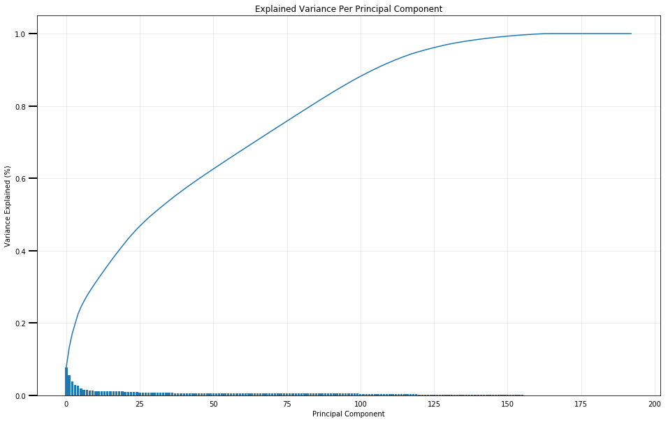

```python
# Investigate the variance accounted for by each principal component.

scree_plot(pca)
```

```python
# Define plot function to check out the ratio of variance explained by each principal component

def plot_variance_ratio(pca):
    '''
    Creates a plot associated with the principal components

    INPUT: pca - the result of instantian of PCA in scikit learn

    OUTPUT:
            None
    '''
    num_components=len(pca.explained_variance_ratio_)
    ind = np.arange(num_components)
    vals = pca.explained_variance_ratio_

    plt.figure(figsize=(16, 10))
    ax = plt.subplot(111)
    #cumvals = np.cumsum(vals)
    ax.bar(ind, vals)
    #ax.plot(ind, cumvals)

    ax.grid()
    ax.set_axisbelow(True)
    ax.grid(linewidth='0.5', alpha=0.5)

    # Printing percentage of variance explained by first 5 components.
    for i in range(ind[5]):
        ax.annotate(r"%s%%" % ((str(vals[i]*100)[:4])), (ind[i]+0.2, vals[i]), va="bottom", ha="center", fontsize=12)

    ax.xaxis.set_tick_params(width=0)
    ax.yaxis.set_tick_params(width=2, length=12)

    ax.set_xlabel("Principal Component")
    ax.set_ylabel("Variance Explained (%)")
    plt.title('Explained Variance Per Principal Component')
```

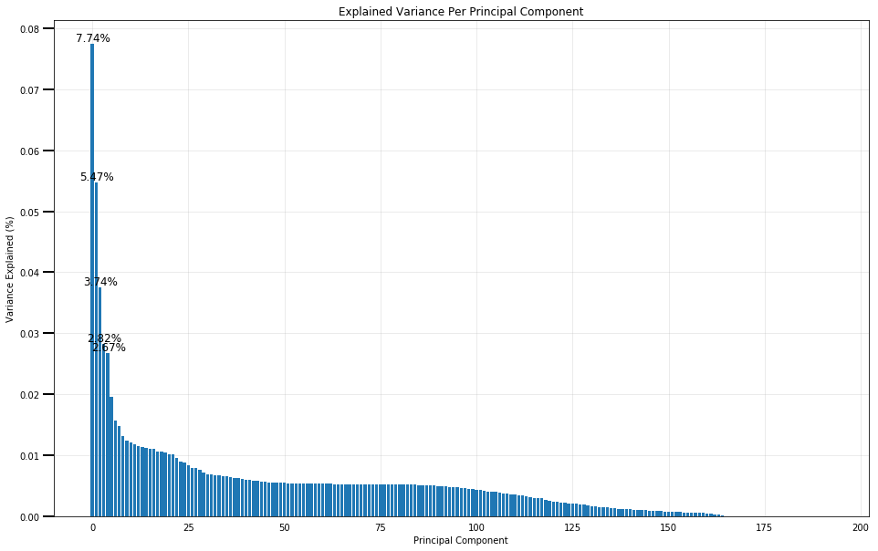

```python
plot_variance_ratio(pca)
```

```python
# Getting cumulative sum of explained variance ratio.

vals = pca.explained_variance_ratio_
cumvals = list(np.cumsum(vals))
for cmv in enumerate(cumvals):
    print(cmv)
```

```
(0, 0.077465331348829644)
(1, 0.13220449151368258)
(2, 0.16966383884122124)
(3, 0.19786928233716389)
(4, 0.22463862482020633)
(5, 0.24414419368662385)
(6, 0.25987974293501553)
(7, 0.27461616010317164)
(8, 0.28782423465902612)
(9, 0.30022148026135692)
(10, 0.31229390614280317)
(11, 0.32415086749130334)
(12, 0.33569495943630256)
(13, 0.34709442444308103)
(14, 0.35835181248784859)
(15, 0.36944377588656713)
(16, 0.38043174604661423)
(17, 0.39105270342502124)
(18, 0.40159796380414686)
(19, 0.41197302056238472)
(20, 0.42218233609182693)
(21, 0.43231607244818704)
(22, 0.44183697895928659)
(23, 0.4507577601204979)
(24, 0.45948787092525428)
(25, 0.46777184511169145)
(26, 0.47574168656427851)
(27, 0.48359296784959949)
(28, 0.49117122962247745)
(29, 0.49832515440842551)
(30, 0.5052442469245354)
(31, 0.51212396333438925)
(32, 0.51877207655236979)
(33, 0.52540729236999884)
(34, 0.53200459289583191)
(35, 0.53851853081512036)
(36, 0.54495835127540093)
(37, 0.55122460349272029)
(38, 0.55741461311867646)
(39, 0.56345786474716208)
```

[output cut: 138 more lines]

```
(178, 0.99999999999999956)
(179, 0.99999999999999956)
(180, 0.99999999999999956)
(181, 0.99999999999999956)
(182, 0.99999999999999956)
(183, 0.99999999999999956)
(184, 0.99999999999999956)
(185, 0.99999999999999956)
(186, 0.99999999999999956)
(187, 0.99999999999999956)
(188, 0.99999999999999956)
(189, 0.99999999999999956)
(190, 0.99999999999999956)
(191, 0.99999999999999956)
(192, 0.99999999999999956)
```

```python
# Define plot function to check out cumulative variance explained by principal components.

def plot_cumulative_variance(pca):
    '''
    Creates a plot associated with the principal components

    INPUT: pca - the result of instantian of PCA in scikit learn

    OUTPUT:
            None
    '''
    num_components=len(pca.explained_variance_ratio_)
    ind = np.arange(num_components)
    vals = pca.explained_variance_ratio_

    plt.figure(figsize=(10, 6))
    ax = plt.subplot(111)
    cumvals = np.cumsum(vals)
    #ax.bar(ind, vals)
    ax.plot(ind, cumvals)

    ax.grid()
    ax.set_axisbelow(True)
    ax.grid(linewidth='0.5', alpha=0.5)

    cumval_ind_hv1 = []
    cumval_ind_hv2 = []
    cumval_ind_hv3 = []
    cumval_ind_hv4 = []
    cumval_ind_hv5 = []
    cumval_ind_hv6 = []
    cumval_ind_hv7 = []
    for i in enumerate(cumvals):
        if i[1] > 0.3 and i[1] < 0.4:
            cumval_ind_hv1.append(i)
        elif i[1] > 0.4 and i[1] < 0.5:
            cumval_ind_hv2.append(i)
        elif i[1] > 0.5 and i[1] < 0.6:
            cumval_ind_hv3.append(i)
        elif i[1] > 0.6 and i[1] < 0.7:
            cumval_ind_hv4.append(i)
        elif i[1] > 0.7 and i[1] < 0.8:
            cumval_ind_hv5.append(i)
        elif i[1] > 0.8 and i[1] < 0.9:
            cumval_ind_hv6.append(i)
        elif i[1] > 0.9:
            cumval_ind_hv7.append(i)

    #print(cumval_ind_hv1[0][0])
    #print(cumval_ind_hv2[0][0])
    #print(cumval_ind_hv3[0][0])
    #print(cumval_ind_hv4[0][0])

    # Plotting horizontal and vertical at points with cumulative variance of 30%, 50%, 60% and 80%.

    plt.hlines(y=0.3, xmin=0, xmax=cumval_ind_hv1[0][0], color='red', linestyles='dashed',zorder=1)
    plt.vlines(x=cumval_ind_hv1[0][0], ymin=0, ymax=0.3, color='red', linestyles='dashed',zorder=2)
    plt.hlines(y=0.4, xmin=0, xmax=cumval_ind_hv2[0][0], color='red', linestyles='dashed',zorder=3)
    plt.vlines(x=cumval_ind_hv2[0][0], ymin=0, ymax=0.4, color='red', linestyles='dashed',zorder=4)
    plt.hlines(y=0.5, xmin=0, xmax=cumval_ind_hv3[0][0], color='red', linestyles='dashed',zorder=5)
    plt.vlines(x=cumval_ind_hv3[0][0], ymin=0, ymax=0.5, color='red', linestyles='dashed',zorder=6)
    plt.hlines(y=0.6, xmin=0, xmax=cumval_ind_hv4[0][0], color='red', linestyles='-',zorder=7)
    plt.vlines(x=cumval_ind_hv4[0][0], ymin=0, ymax=0.6, color='red', linestyles='-',zorder=8)
    plt.hlines(y=0.7, xmin=0, xmax=cumval_ind_hv5[0][0], color='red', linestyles='dashed',zorder=9)
    plt.vlines(x=cumval_ind_hv5[0][0], ymin=0, ymax=0.7, color='red', linestyles='dashed',zorder=10)
    plt.hlines(y=0.8, xmin=0, xmax=cumval_ind_hv6[0][0], color='red', linestyles='dashed',zorder=11)
    plt.vlines(x=cumval_ind_hv6[0][0], ymin=0, ymax=0.8, color='red', linestyles='dashed',zorder=12)
    plt.hlines(y=0.9, xmin=0, xmax=cumval_ind_hv7[0][0], color='red', linestyles='dashed',zorder=13)
    plt.vlines(x=cumval_ind_hv7[0][0], ymin=0, ymax=0.9, color='red', linestyles='dashed',zorder=14)

    # Plotting number of components for cumulative variance of 30%, 50%, 60% and 80%.
    for i,v in [cumval_ind_hv1[0], cumval_ind_hv2[0], cumval_ind_hv3[0],\
                cumval_ind_hv4[0], cumval_ind_hv5[0], cumval_ind_hv6[0],
                cumval_ind_hv7[0]]:
        ax.annotate(r"%s" % ((str(i+1))), (i+0.2, np.round(v, 2)), va="bottom", ha="center", fontsize=12)



    ax.xaxis.set_tick_params(width=0)
    ax.yaxis.set_tick_params(width=2, length=12)

    ax.set_xlabel("Principal Component")
    ax.set_ylabel("Variance Explained (%)")
    plt.title('Cumulative Variance of Principal Components')
```

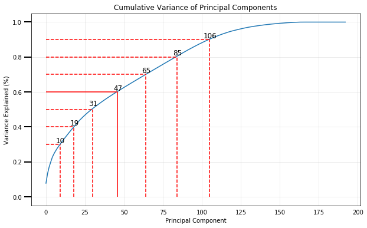

```python
plot_cumulative_variance(pca)
```

```python
# Re-apply PCA to the data while selecting for number of components to retain.

pca_31, azdias_pca = do_pca(31,azdias_scaled)
```

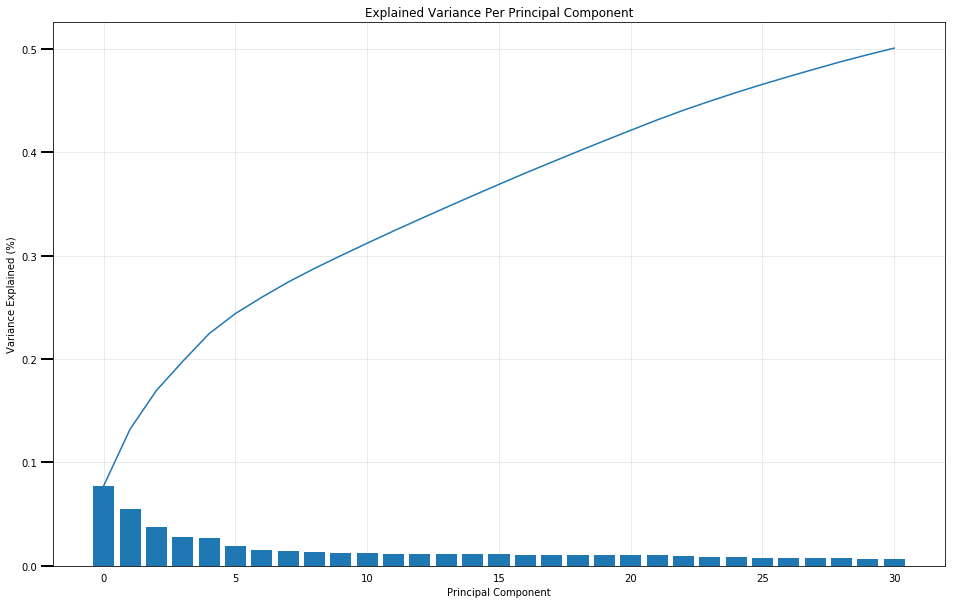

```python
scree_plot(pca_31)
```

### Discussion 2.2: Perform Dimensionality Reduction

Before performing dimensionality reduction we had 193 features in the dataset which were cleaned, imputed, scaled and ready to use. We passed the features through PCA process to obtain principal components in the directions of maximum variance. We then visualized the explained variance ratio per principal components and cumulative variance ratio of principal components.

From the plot of cumulative variance of principal components, we can observe that with every 10% increase of variance, the number of components required for the same increase kept on increasing i.e. to get 10 % increase from 30% to 40% to 50% to 60% to 70% to 80% to 90% of the total variance, it required to increase components from 10 to 19 to 31 to 47 to 65 to 85 to 106 which corresponds to increase of 9 to 12 to 16 to 18 to 20 to 21 components respectively.

At 31, 47, 65 and 85 principal components, we had 50%, 60%, 70% and 80% of the total variance of the dataset.

Looking at the "Cumulative Explained Variance of Principal Components", there seemed to be a good trade-off at 85 components at which 193 features are reduced to 85(principal components) and still maintained 80% of the dataset variance. But we also know that components from around 30th component to 105th component provide same explained variance of between 0.005 to 0.006 which is very low and remain same throughout the interval. From the plot, we can also observe the somewhat linear relationship of explained variance ratio to principal components from around 30-105 component interval. The components between this interval appears to be similar and therefore would not help out in differentiating the customer segments. The components in 30-105 interval would not have that much impact later on when we perform the cluster analysis to have the customer segmentation. These components would not be that helpful in generalizing the customer segments well and clearly. May be these components would be helpful in secondary segmentation or detailed segmentation. Components from 105th component onwards has very less explained variance and can be excluded for further analysis as they would have very little to no effect on customer segmentation.

So, proceeding with 31 principal components which explains 50% of the total variance in the dataset and should be helpful to much extent in generalizing the customer segments during cluster analysis process.

### Step 2.3: Interpret Principal Components

Now that we have our transformed principal components, it's a nice idea to check out the weight of each variable on the first few components to see if they can be interpreted in some fashion.

As a reminder, each principal component is a unit vector that points in the direction of highest variance (after accounting for the variance captured by earlier principal components). The further a weight is from zero, the more the principal component is in the direction of the corresponding feature. If two features have large weights of the same sign (both positive or both negative), then increases in one tend expect to be associated with increases in the other. To contrast, features with different signs can be expected to show a negative correlation: increases in one variable should result in a decrease in the other.

- To investigate the features, you should map each weight to their corresponding feature name, then sort the features according to weight. The most interesting features for each principal component, then, will be those at the beginning and end of the sorted list. Use the data dictionary document to help you understand these most prominent features, their relationships, and what a positive or negative value on the principal component might indicate.
- You should investigate and interpret feature associations from the first three principal components in this substep. To help facilitate this, you should write a function that you can call at any time to print the sorted list of feature weights, for the *i*-th principal component. This might come in handy in the next step of the project, when you interpret the tendencies of the discovered clusters.

```python
# Principal components of pca_31 in feature space, representing the directions of maximum variance in the data.
pca_31.components_
```

```
array([[-0.09254817,  0.0183973 , -0.18985379, ..., -0.11905432,
        -0.12666772,  0.1432197 ],
       [ 0.2245605 ,  0.01890788,  0.0761277 , ...,  0.0272614 ,
        -0.05298637,  0.05459576],
       [-0.04072776, -0.24729457,  0.03068545, ...,  0.05342803,
        -0.00109888,  0.01577757],
       ...,
       [ 0.01857833, -0.02445757,  0.00327582, ..., -0.02916442,
         0.04186463, -0.04898982],
       [ 0.06793146, -0.00819494, -0.01228616, ..., -0.05090903,
         0.01301602, -0.00408424],
       [ 0.05563068, -0.01506229, -0.0068309 , ...,  0.14350594,
         0.05301854, -0.02524677]])
```

```python
# The amount of variance explained by each of the selected component in pca_31.
pca_31.explained_variance_
```

```
array([ 14.95082832,  10.56467149,   7.2296596 ,   5.44364945,
         5.16647952,   3.76439633,   3.03646637,   2.84247665,
         2.54516434,   2.38850306,   2.32523525,   2.28353867,
         2.21699451,   2.1937688 ,   2.16296531,   2.13254386,
         2.10591943,   2.03285541,   2.02174067,   1.98284012,
         1.95431955,   1.93242809,   1.81368759,   1.6825819 ,
         1.62386875,   1.53135288,   1.46228229,   1.41384831,
         1.38526945,   1.28274323,   1.22691656])
```

```python
# Percentage of variance explained by each of the selected components in pca_31.
pca_31.explained_variance_ratio_
```

```
array([ 0.07746533,  0.05473916,  0.03745933,  0.0282054 ,  0.02676929,
        0.01950462,  0.01573297,  0.01472784,  0.01318736,  0.01237565,
        0.01204784,  0.01183179,  0.011487  ,  0.01136666,  0.01120706,
        0.01104944,  0.01091149,  0.01053292,  0.01047533,  0.01027377,
        0.01012599,  0.01001257,  0.00939733,  0.00871803,  0.00841382,
        0.00793446,  0.00757658,  0.00732563,  0.00717755,  0.00664633,
        0.00635707])
```

```python
# Create a dataframe of Explained Variance ratio in pca_31.
dimensions = ['PC {}'.format(i) for i in range(1,len(pca_31.components_)+1)]
ratios = pca_31.explained_variance_ratio_
variance_ratios = pd.DataFrame(np.round(ratios, 4), columns = ['EXPLAINED_VARIANCE'])
variance_ratios.index = dimensions
```

```python
variance_ratios
```

|  | EXPLAINED_VARIANCE |
| --- | --- |
| PC 1 | 0.0775 |
| PC 2 | 0.0547 |
| PC 3 | 0.0375 |
| PC 4 | 0.0282 |
| PC 5 | 0.0268 |
| PC 6 | 0.0195 |
| PC 7 | 0.0157 |
| PC 8 | 0.0147 |
| PC 9 | 0.0132 |
| PC 10 | 0.0124 |
| PC 11 | 0.0120 |
| PC 12 | 0.0118 |
| PC 13 | 0.0115 |
| PC 14 | 0.0114 |
| PC 15 | 0.0112 |
| PC 16 | 0.0110 |
| PC 17 | 0.0109 |
| PC 18 | 0.0105 |
| PC 19 | 0.0105 |
| PC 20 | 0.0103 |
| PC 21 | 0.0101 |
| PC 22 | 0.0100 |
| PC 23 | 0.0094 |
| PC 24 | 0.0087 |
| PC 25 | 0.0084 |
| PC 26 | 0.0079 |
| PC 27 | 0.0076 |
| PC 28 | 0.0073 |
| PC 29 | 0.0072 |
| PC 30 | 0.0066 |
| PC 31 | 0.0064 |

```python
# Create a dataframe with the weights for each principal component in pca_31.
# Map weights for the principal components to corresponding feature names.

components_weights = pd.DataFrame(np.round(pca_31.components_, 4), columns = azdias_scaled.keys())
components_weights.index = dimensions
```

```python
components_weights.head()
```

|  | ALTERSKATEGORIE_GROB | ANREDE_KZ | FINANZ_MINIMALIST | FINANZ_SPARER | FINANZ_VORSORGER | FINANZ_ANLEGER | FINANZ_UNAUFFAELLIGER | FINANZ_HAUSBAUER | GREEN_AVANTGARDE | HEALTH_TYP | ... | CAMEO_DEU_2015_9B | CAMEO_DEU_2015_9C | CAMEO_DEU_2015_9D | CAMEO_DEU_2015_9E | PRAEGENDE_JUGENDJAHRE_decade | PRAEGENDE_JUGENDJAHRE_movement | CAMEO_INTL_2015_wealth | CAMEO_INTL_2015_life_stage | WOHNLAGE_rural | WOHNLAGE_rating_class |
| --- | --- | --- | --- | --- | --- | --- | --- | --- | --- | --- | --- | --- | --- | --- | --- | --- | --- | --- | --- | --- | --- |
| PC 1 | -0.0925 | 0.0184 | -0.1899 | 0.1288 | -0.0929 | 0.0759 | 0.0771 | 0.1384 | -0.1054 | 0.0475 | ... | 0.0528 | 0.0541 | 0.0535 | 0.0142 | 0.0955 | 0.1054 | 0.1852 | -0.1191 | -0.1267 | 0.1432 |
| PC 2 | 0.2246 | 0.0189 | 0.0761 | -0.2281 | 0.2168 | -0.2188 | -0.2218 | 0.0982 | 0.0029 | -0.0739 | ... | 0.0140 | 0.0179 | 0.0223 | 0.0417 | -0.2344 | -0.0029 | 0.0457 | 0.0273 | -0.0530 | 0.0546 |
| PC 3 | -0.0407 | -0.2473 | 0.0307 | -0.0113 | -0.0221 | -0.1258 | -0.0775 | -0.0278 | 0.0673 | -0.0659 | ... | 0.0355 | 0.0384 | 0.0241 | -0.0027 | -0.0322 | -0.0673 | -0.0454 | 0.0534 | -0.0011 | 0.0158 |
| PC 4 | 0.0130 | -0.1667 | 0.1352 | -0.0230 | 0.0466 | -0.0641 | 0.0861 | -0.0860 | 0.1868 | 0.0552 | ... | -0.0267 | -0.0046 | -0.0109 | -0.0073 | 0.0090 | -0.1868 | 0.0307 | -0.0647 | -0.1699 | 0.1021 |
| PC 5 | -0.0383 | 0.2000 | -0.0779 | 0.0262 | -0.0468 | -0.0203 | 0.0036 | 0.0142 | 0.2277 | -0.0342 | ... | 0.0060 | 0.0031 | -0.0017 | 0.0004 | 0.0254 | -0.2277 | -0.1031 | 0.0847 | -0.1233 | 0.0747 |

5 rows × 193 columns

```python
# Map weights for the first principal component to corresponding feature names
# and then print the linked values, sorted by weight.
# HINT: Try defining a function here or in a new cell that you can reuse in the
# other cells.

# Highest positive and negative weights for the first Principal Componnent

def weights_sorted_p_comp(n_p_comp, n_weights):
    p_comp = 'PC' + ' ' + str(n_p_comp)
    print("Principal Component", (n_p_comp))
    print('-' * 30)
    print("\nTop positive weights are below\n")
    print(components_weights.loc[p_comp].sort_values(ascending=False)[:n_weights])
    print('-' * 30)
    print("\nTop negative weights are below\n")
    print(components_weights.loc[p_comp].sort_values()[:n_weights])
```

```python
# Plot the feature weights as a function of the components
def plot_component_weights(n_p_comp, n_weights):
    '''
    n_p_comp: prinicipal component number
    n_weights: number of top positive and top negative weights
    '''
    p_comp = 'PC' + ' ' + str(n_p_comp)
    comp_weight_first_last = components_weights.loc[p_comp].sort_values(ascending=False)[:n_weights].append(
                                    components_weights.loc[p_comp].sort_values()[:n_weights])

    # Create a bar plot visualization
    fig, ax = plt.subplots(figsize = (10,6))
    comp_weight_first_last.plot(ax = ax, kind = 'bar')

    # Turn on the grid
    ax.grid()

    # Don't allow the axis to be on top of your data
    ax.set_axisbelow(True)

    # Customize the grid
    ax.grid(linewidth='0.5', alpha=0.5)

    #comp_weight_first_last.plot(ax = ax, kind = 'bar')
    ax.set_ylabel("Feature Weights")
    #ax.set_xticklabels(list(comp_weight_first_last.index), rotation='vertical')
    plt.show()
```

```python
# Getting top 5 positive and negative weights of a principal component 1.
weights_sorted_p_comp(1, 5)
```

```
Principal Component 1
------------------------------

Top positive weights are below

CAMEO_INTL_2015_wealth    0.1852
PLZ8_ANTG3                0.1843
LP_STATUS_GROB_1.0        0.1792
EWDICHTE                  0.1633
ORTSGR_KLS9               0.1565
Name: PC 1, dtype: float64
------------------------------

Top negative weights are below

FINANZ_MINIMALIST   -0.1899
MOBI_REGIO          -0.1879
PLZ8_ANTG1          -0.1822
KBA05_ANTG1         -0.1816
KBA05_GBZ           -0.1780
Name: PC 1, dtype: float64
```

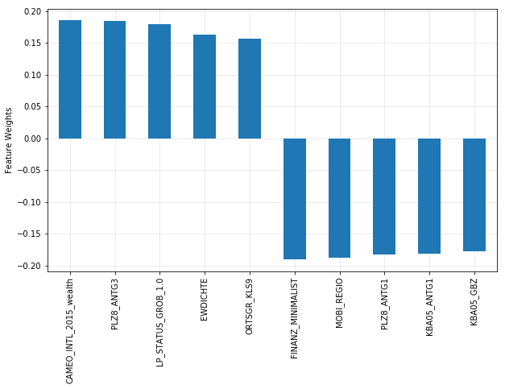

```python
# Plotting the top 5 positive and negative weights of a principal component 1.
plot_component_weights(1, 5)
```

```python
# Map weights for the second principal component to corresponding feature names
# and then print the linked values, sorted by weight.

# Getting top 5 positive and negative weights of a principal component 2.
weights_sorted_p_comp(2, 5)
```

```
Principal Component 2
------------------------------

Top positive weights are below

ALTERSKATEGORIE_GROB    0.2246
FINANZ_VORSORGER        0.2168
SEMIO_ERL               0.1742
RETOURTYP_BK_S          0.1573
ZABEOTYP_3              0.1507
Name: PC 2, dtype: float64
------------------------------

Top negative weights are below

PRAEGENDE_JUGENDJAHRE_decade   -0.2344
FINANZ_SPARER                  -0.2281
FINANZ_UNAUFFAELLIGER          -0.2218
FINANZ_ANLEGER                 -0.2188
SEMIO_REL                      -0.2113
Name: PC 2, dtype: float64
```

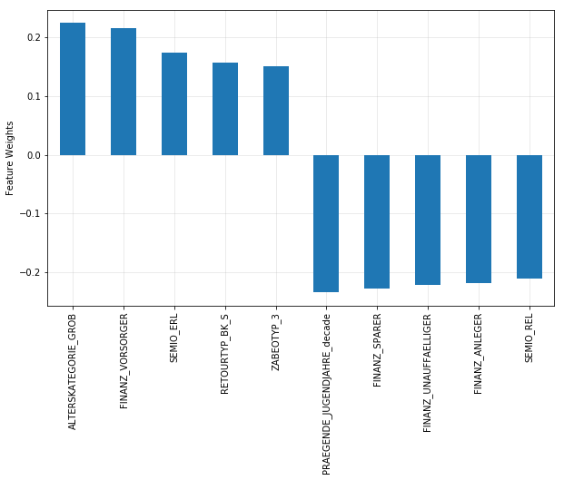

```python
# Plotting the top 5 positive and negative weights of a principal component 2.
plot_component_weights(2, 5)
```

```python
# Map weights for the third principal component to corresponding feature names
# and then print the linked values, sorted by weight.

# Getting top 5 positive and negative weights of a principal component 3.
weights_sorted_p_comp(3, 5)
```

```
Principal Component 3
------------------------------

Top positive weights are below

SEMIO_VERT         0.2991
SEMIO_KULT         0.2690
SEMIO_SOZ          0.2663
SEMIO_FAM          0.1607
SHOPPER_TYP_0.0    0.1280
Name: PC 3, dtype: float64
------------------------------

Top negative weights are below

SEMIO_KRIT   -0.2841
SEMIO_KAEM   -0.2814
SEMIO_DOM    -0.2501
ANREDE_KZ    -0.2473
ZABEOTYP_3   -0.1725
Name: PC 3, dtype: float64
```

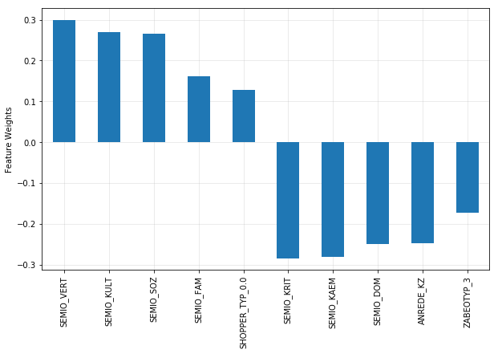

```python
# Plotting the top 5 positive and negative weights of a principal component 3.
plot_component_weights(3, 5)
```

### Discussion 2.3: Interpret Principal Components

The first 5 principal components make up 22.46% of the total variance of the dataset. The first component makes up 7.74% of the total variance.

Each component is a combination of the 193 features left after cleaning, with each feature given a weight relative to its importance for a particular principal component. The higher the weight either positive or negative, the more impact the feature has on the calculation of the principal component. What value of weight is important is subjective and depends on the context.

We have taken the top 5 highest postive weights and negative weights to interpret the first 3 principal components.

The first principal component has positive weights with features mentioned below:

- CAMEO_INTL_2015_wealth - Household Wealth Typology(Household wealth (higher is lower household or income)
- PLZ8_ANTG3 - Number of 6-10 family houses in the PLZ8 region(higher is higher number)
- LP_STATUS_GROB_1.0 - Social status, low-income earners
- EWDICHTE - Density of households per square kilometer(higher is higher density)
- ORTSGR_KLS9 - Size of community(higher is higher size)

The first principal component has negative weights with features mentioned below:

- FINANZ_MINIMALIST - Financial typology, low financial interest(higher is lower topology)
- MOBI_REGIO - Movement patterns(higher is lower movement)
- PLZ8_ANTG1 - Number of 1-2 family houses in the PLZ8 region(higher is higher share)
- KBA05_ANTG1 - Number of 1-2 family houses in the microcell(higher is higher share)
- KBA05_GBZ - Number of buildings in the microcell(higher is more buildings)

The second principal component have positive weights with features mentioned below:

- ALTERSKATEGORIE_GROB - Estimated age
- FINANZ_VORSORGER - Financial typology(be prepared)
- SEMIO_ERL - Personality typology(event-oriented)
- RETOURTYP_BK_S - return shopper type
- ZABEOTYP_3 - Energy consumption typology(fair supplied)

The second principal component have negative weights with features mentioned below:

- PRAEGENDE_JUGENDJAHRE_decade - Decade of movement of person's youth (higher is higher, highest is 90s)
- FINANZ_SPARER - Financial typology, money-saver(higher is lower topology)
- FINANZ_UNAUFFAELLIGER - Financial typology, inconspicuous(higher is lower topology)
- FINANZ_ANLEGER - Financial typology, investor(higher is lower topology)
- SEMIO_REL - Personality typology, religious(higher is lower affinity

The second principal component seems to be representing a combination of features related age, decade of movement, personality types of individuals, energy consumption pattern and financial savings. It relates to individuals of older people with conservative traditional values. Positive correlations with increasing age and financial prudence.

The third principal component have positive weights with features mentioned below:

- SEMIO_VERT - Personality typology, dreamful(higher is lower affinity)
- SEMIO_KULT - Personality typology, cultural-minded(higher is lower affinity)
- SEMIO_SOZ - Personality typology, socially-minded(higher is lower affinity)
- SEMIO_FAM - Personality typology, family-minded(higher is lower affinity)
- SHOPPER_TYP_0.0 - Shopper typology, external supplied hedonists

The third principal component have negative weights with features mentioned below:

- SEMIO_KRIT - Personality typology, critical-minded(higher is lower affinity)
- SEMIO_KAEM - Personality typology, combative attitude(higher is lower affinity)
- SEMIO_DOM - Personality typology, dominant-minded(higher is lower affinity)
- ANREDE_KZ - Gender(1 is male, 2 is female)
- ZABEOTYP_3 - Energy consumption typology(fair supplied)

The third principal component is related to the personaly traits and gender. For instance, it separates family-minded and social females vs dominant and combative males. It seems to be representing a combination of features related to individuals of female gender with a humanitarian disposition.

## Step 3: Clustering

### Step 3.1: Apply Clustering to General Population

You've assessed and cleaned the demographics data, then scaled and transformed them. Now, it's time to see how the data clusters in the principal components space. In this substep, you will apply k-means clustering to the dataset and use the average within-cluster distances from each point to their assigned cluster's centroid to decide on a number of clusters to keep.

- Use sklearn's KMeans class to perform k-means clustering on the PCA-transformed data.
- Then, compute the average difference from each point to its assigned cluster's center. **Hint**: The KMeans object's `.score()` method might be useful here, but note that in sklearn, scores tend to be defined so that larger is better. Try applying it to a small, toy dataset, or use an internet search to help your understanding.
- Perform the above two steps for a number of different cluster counts. You can then see how the average distance decreases with an increasing number of clusters. However, each additional cluster provides a smaller net benefit. Use this fact to select a final number of clusters in which to group the data. **Warning**: because of the large size of the dataset, it can take a long time for the algorithm to resolve. The more clusters to fit, the longer the algorithm will take. You should test for cluster counts through at least 10 clusters to get the full picture, but you shouldn't need to test for a number of clusters above about 30.
- Once you've selected a final number of clusters to use, re-fit a KMeans instance to perform the clustering operation. Make sure that you also obtain the cluster assignments for the general demographics data, since you'll be using them in the final Step 3.3.

```python
# Printing type of azdias_pca
type(azdias_pca)
```

```
numpy.ndarray
```

```python
# Printing shape of azdias_pca
azdias_pca.shape
```

```
(771701, 31)
```

```python
azdias_pca[:5]
```

```
array([[ 2.68075056, -1.02728496, -3.84800634,  3.27278736, -2.0988082 ,
         1.27095657, -0.61606248, -0.37837411,  0.03751098,  2.80148878,
        -2.22926907,  2.29018191, -0.08188436,  0.49479624, -0.60929208,
         0.17323504,  0.03060286,  0.05011703, -0.3312987 , -0.16699912,
        -0.22692365,  0.92864172, -1.58314699,  0.18699686, -0.36633568,
         0.09863777, -1.15601609, -1.26316924, -0.09110773,  0.84584534,
        -0.1034491 ],
       [ 5.08478668, -3.39901327, -0.43862804, -2.57994205,  2.8443638 ,
         0.29325725,  1.85396089, -0.60459409,  0.72357709,  0.67218137,
        -2.39570857, -1.21862779, -2.05851765,  2.09732216, -1.18445002,
         0.54009173,  2.76381577,  4.76888731,  3.37809028,  0.29636037,
        -0.6596954 , -0.35128515, -1.2965607 , -1.13549627,  1.06522947,
        -0.04189834, -0.53824861,  1.4239446 , -2.27804203,  1.39532048,
        -0.7511803 ],
       [-0.64177296, -0.45528716, -1.33971423, -1.80497383,  3.06206261,
        -4.32520266,  0.94195871, -1.14190251,  0.20846502, -2.10041708,
        -0.81747251,  0.01324509,  0.01385692,  1.97024684, -0.12641522,
        -1.87761236, -1.34709717, -0.88121517, -1.55054011, -0.77366834,
        -0.89358499, -1.75741514,  1.3104257 ,  0.98078116, -1.22347731,
         0.64047826, -1.22103821,  0.41024602, -0.55318192, -0.43594035,
         1.67876624],
       [-5.44978737,  1.28212435, -1.24466075, -2.12740835, -1.60661422,
         0.20376778, -2.0134398 ,  0.99309607, -1.3511125 ,  0.91126384,
        -0.73633965, -0.12024852, -1.44775837, -1.66457278,  1.29689281,
         1.05840521,  2.13784627,  0.61304535, -1.33744945,  0.93855945,
         0.71208722, -0.57255647,  1.61212952, -1.69565096, -0.31739084,
         1.32258872,  0.66115159,  1.33969813, -0.76952814, -0.09546156,
        -0.17157938],
       [-0.33692845,  0.97373439,  2.79285676,  2.00612883,  0.37801322,
         2.95672891,  2.38441444, -3.42136671,  2.18600037, -3.25054724,
         1.90381653,  1.07110911,  2.52457106, -0.50202663,  1.26113813,
        -0.17760581,  0.52367171,  0.39045085, -1.1278602 ,  0.04098737,
         0.62363229, -0.62117874,  1.9383166 , -0.63531985, -2.366961  ,
        -0.45781669, -0.22960519,  0.69504076,  2.03564954, -0.29412205,
        -0.12572034]])
```

```python
def get_kmeans_score(data, center):
    '''
    returns the kmeans score regarding SSE for points to centers
    INPUT:
        data - the dataset you want to fit kmeans to
        center - the number of centers you want (the k value)
    OUTPUT:
        score - the SSE score for the kmeans model fit to the data
    '''
    #instantiate kmeans
    kmeans = KMeans(n_clusters=center)

    # Then fit the model to your data using the fit method
    model = kmeans.fit(data)

    # Obtain a score related to the model fit
    score = np.abs(model.score(data))

    return score
```

```python
# Over a number of different cluster counts...
# run k-means clustering on the data and...
# compute the average within-cluster distances.

scores = []
centers = list(range(2,31,1))

for center in centers:
    score = round(get_kmeans_score(azdias_pca, center),2)
    print('center : {}     score : {}'.format(center, score))
    scores.append(score)
```

```
center : 2     score : 65965041.76
center : 3     score : 61448400.74
center : 4     score : 57690034.06
center : 5     score : 54941190.83
center : 6     score : 52944556.58
center : 7     score : 51610033.4
center : 8     score : 50499042.86
center : 9     score : 49366495.24
center : 10     score : 48354190.0
center : 11     score : 47390682.19
center : 12     score : 46599760.77
center : 13     score : 45930307.82
center : 14     score : 45203943.79
center : 15     score : 44774540.7
center : 16     score : 44272728.5
center : 17     score : 43966267.86
center : 18     score : 43226751.69
center : 19     score : 42771942.43
center : 20     score : 42393716.99
center : 21     score : 42050685.45
center : 22     score : 41438328.19
center : 23     score : 40706910.51
center : 24     score : 40448509.55
center : 25     score : 40572295.12
center : 26     score : 39969990.14
center : 27     score : 39708681.96
center : 28     score : 39199860.67
center : 29     score : 38896389.24
center : 30     score : 38650262.26
```

```python
# Create dataframe showing the average point-centroid distances
scores_ds = pd.Series(scores)
centers_ds = pd.Series(centers)
scores_df = pd.concat([centers_ds,scores_ds],axis=1)
scores_df.columns = ['clusters','average_distance']
scores_df.set_index('clusters',inplace=True)
scores_df['average_distance'] = scores_df['average_distance'].round(2)
scores_df
```

[output not shown]

```python
# Save checkpoint
#scores_df.to_csv('scores_checkpoint.csv',sep=';',encoding='utf-8',index=False)
scores_df.to_csv('scores_checkpoint.csv',sep=';',encoding='utf-8')
```

```python
# Load scores_checkpoint.csv
scores_df = pd.read_csv('scores_checkpoint.csv', delimiter=';')
```

```python
scores_df
```

|  | clusters | average_distance |
| --- | --- | --- |
| 0 | 2 | 65965041.76 |
| 1 | 3 | 61448400.74 |
| 2 | 4 | 57690034.06 |
| 3 | 5 | 54941190.83 |
| 4 | 6 | 52944556.58 |
| 5 | 7 | 51610033.40 |
| 6 | 8 | 50499042.86 |
| 7 | 9 | 49366495.24 |
| 8 | 10 | 48354190.00 |
| 9 | 11 | 47390682.19 |
| 10 | 12 | 46599760.77 |
| 11 | 13 | 45930307.82 |
| 12 | 14 | 45203943.79 |
| 13 | 15 | 44774540.70 |
| 14 | 16 | 44272728.50 |
| 15 | 17 | 43966267.86 |
| 16 | 18 | 43226751.69 |
| 17 | 19 | 42771942.43 |
| 18 | 20 | 42393716.99 |
| 19 | 21 | 42050685.45 |
| 20 | 22 | 41438328.19 |
| 21 | 23 | 40706910.51 |
| 22 | 24 | 40448509.55 |
| 23 | 25 | 40572295.12 |
| 24 | 26 | 39969990.14 |
| 25 | 27 | 39708681.96 |
| 26 | 28 | 39199860.67 |
| 27 | 29 | 38896389.24 |
| 28 | 30 | 38650262.26 |

```python
scores_df.set_index('clusters',inplace=True)
```

```python
scores_df
```

| clusters | average_distance |
| --- | --- |
| 2 | 65965041.76 |
| 3 | 61448400.74 |
| 4 | 57690034.06 |
| 5 | 54941190.83 |
| 6 | 52944556.58 |
| 7 | 51610033.40 |
| 8 | 50499042.86 |
| 9 | 49366495.24 |
| 10 | 48354190.00 |
| 11 | 47390682.19 |
| 12 | 46599760.77 |
| 13 | 45930307.82 |
| 14 | 45203943.79 |
| 15 | 44774540.70 |
| 16 | 44272728.50 |
| 17 | 43966267.86 |
| 18 | 43226751.69 |
| 19 | 42771942.43 |
| 20 | 42393716.99 |
| 21 | 42050685.45 |
| 22 | 41438328.19 |
| 23 | 40706910.51 |
| 24 | 40448509.55 |
| 25 | 40572295.12 |
| 26 | 39969990.14 |
| 27 | 39708681.96 |
| 28 | 39199860.67 |
| 29 | 38896389.24 |
| 30 | 38650262.26 |

```python
centers =  list(scores_df.index)
scores = scores_df['average_distance'].values.tolist()


# Added below variable avg_point_centroid_dist as per suggestion provided in the poject review.
avg_point_centroid_dist = round(scores_df['average_distance']/azdias_pca.shape[0], 2)
```

```python
avg_point_centroid_dist
```

```
clusters
2     85.48
3     79.63
4     74.76
5     71.19
6     68.61
7     66.88
8     65.44
9     63.97
10    62.66
11    61.41
12    60.39
13    59.52
14    58.58
15    58.02
```

[output cut: 16 more lines]

```python
print(type(centers))
print(type(scores))
print(type(list(avg_point_centroid_dist)))
```

```
<class 'list'>
<class 'list'>
<class 'list'>
```

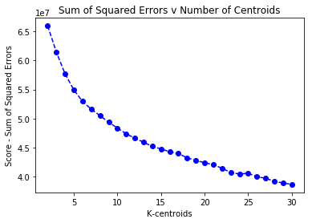

```python
# Investigate the change in within-cluster distance across number of clusters.
# HINT: Use matplotlib's plot function to visualize this relationship.

plt.plot(centers, scores, linestyle='--', marker='o', color='b');
plt.xlabel('K-centroids');
plt.ylabel('Score - Sum of Squared Errors');
plt.title('Sum of Squared Errors v Number of Centroids');
```

```python
print(type(list(avg_point_centroid_dist)))
```

```
<class 'list'>
```

#### Added below plot as per suggestion provided in the project review.

#### Suggestion: Try visualizing the average point-centroid distances.\

#### You can do this by dividing the score by number of rows in the dataset, i.e; score/azdias_pca.shape[0]

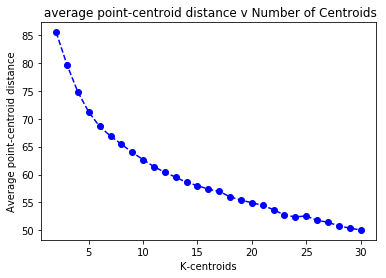

```python
# Investigate the change in within-cluster distance across number of clusters.
# HINT: Use matplotlib's plot function to visualize this relationship.

# Added below plot as per suggestion provided in the project review.
# Suggestion: Try visualizing the average point-centroid distances.\
# You can do this by dividing the score by number of rows in the dataset, i.e; score/azdias_pca.shape[0]

plt.plot(centers, list(avg_point_centroid_dist), linestyle='--', marker='o', color='b');
plt.xlabel('K-centroids');
plt.ylabel('Average point-centroid distance');
plt.title(' average point-centroid distance v Number of Centroids');
```

```python
# Re-fit the k-means model with the selected number of clusters and obtain
# cluster predictions for the general population demographics data.


#instantiate kmeans
kmeans_10 = KMeans(n_clusters=10, n_init=10, max_iter=300, random_state=42)

# Then fit the model to your data using the fit method
model_general = kmeans_10.fit(azdias_pca)

# Finally predict the labels or clusters on the same data using the predict method
predict_general_clusters = model_general.predict(azdias_pca)
```

```python
predict_general_clusters[:5]
```

```
array([9, 4, 2, 0, 7], dtype=int32)
```

```python
len(predict_general_clusters)
```

```
771701
```

```python
np.unique(predict_general_clusters)
```

```
array([0, 1, 2, 3, 4, 5, 6, 7, 8, 9], dtype=int32)
```

### Discussion 3.1: Apply Clustering to General Population

From the above plot of score(SSE) vs. K-centroids, we can observe that the average within-cluster distances from each point to their assigned cluster's centroid decreases with increasing number of clusters. However, the rate of change of slope decreases with additional cluster i.e. each additional cluster provides a smaller net benefit.

Running the K-Means algorithm with 31 principal components didn't provided any defined and clear "elbow". Possible cluster candidates are 6, 7, 10, 11, 16, 17, 20 and 21 depending if you take a high "elbow" at 6 or 7 clusters, "middle" elbow at 10 or 11 clusters or low "elbow" at 16 or 17 clusters.

The rate of change of slope was substantial till 7 clusters and starts to be consistent around 7 clusters and additional clusters later on provided a smaller net benefit. In general, lower number of clusters could provide more equal distribution in the population clustering of the dataset, whereas a higher number of clusters could result in the population clustering having some wide differences between counts allocated to clusters. Keeping the above points in mind, we could take 10 clusters as a choice to segment the population generally.

### Step 3.2: Apply All Steps to the Customer Data

Now that you have clusters and cluster centers for the general population, it's time to see how the customer data maps on to those clusters. Take care to not confuse this for re-fitting all of the models to the customer data. Instead, you're going to use the fits from the general population to clean, transform, and cluster the customer data. In the last step of the project, you will interpret how the general population fits apply to the customer data.

- Don't forget when loading in the customers data, that it is semicolon (`;`) delimited.
- Apply the same feature wrangling, selection, and engineering steps to the customer demographics using the `clean_data()` function you created earlier. (You can assume that the customer demographics data has similar meaning behind missing data patterns as the general demographics data.)
- Use the sklearn objects from the general demographics data, and apply their transformations to the customers data. That is, you should not be using a `.fit()` or `.fit_transform()` method to re-fit the old objects, nor should you be creating new sklearn objects! Carry the data through the feature scaling, PCA, and clustering steps, obtaining cluster assignments for all of the data in the customer demographics data.

```python
# Load in the customer demographics data.
customers = pd.read_csv('Udacity_CUSTOMERS_Subset.csv', delimiter=';')
```

```python
# Shape of customers demographic dataset
customers.shape
```

```
(191652, 85)
```

```python
# Apply preprocessing, feature transformation, and clustering from the general
# demographics onto the customer data, obtaining cluster predictions for the
# customer demographics data.

# Clean Customers subset file.
customers_cleaned = clean_data(customers)
```

```python
type(customers_cleaned)
```

```
pandas.core.frame.DataFrame
```

```python
# Shape of customers demographic dataset after cleaning
customers_cleaned.shape
```

```
(135799, 193)
```

```python
list(customers_cleaned.columns.values)
```

```
['ALTERSKATEGORIE_GROB',
 'ANREDE_KZ',
 'FINANZ_MINIMALIST',
 'FINANZ_SPARER',
 'FINANZ_VORSORGER',
 'FINANZ_ANLEGER',
 'FINANZ_UNAUFFAELLIGER',
 'FINANZ_HAUSBAUER',
 'GREEN_AVANTGARDE',
 'HEALTH_TYP',
 'RETOURTYP_BK_S',
 'SEMIO_SOZ',
 'SEMIO_FAM',
 'SEMIO_REL',
 'SEMIO_MAT',
 'SEMIO_VERT',
 'SEMIO_LUST',
 'SEMIO_ERL',
 'SEMIO_KULT',
 'SEMIO_RAT',
 'SEMIO_KRIT',
 'SEMIO_DOM',
 'SEMIO_KAEM',
 'SEMIO_PFLICHT',
 'SEMIO_TRADV',
 'SOHO_KZ',
 'VERS_TYP',
 'ANZ_PERSONEN',
 'ANZ_TITEL',
 'HH_EINKOMMEN_SCORE',
 'W_KEIT_KIND_HH',
 'WOHNDAUER_2008',
 'ANZ_HAUSHALTE_AKTIV',
 'ANZ_HH_TITEL',
 'KONSUMNAEHE',
 'MIN_GEBAEUDEJAHR',
 'OST_WEST_KZ',
 'KBA05_ANTG1',
 'KBA05_ANTG2',
 'KBA05_ANTG3',
```

[output cut: 138 more lines]

```
 'CAMEO_DEU_2015_8A',
 'CAMEO_DEU_2015_8B',
 'CAMEO_DEU_2015_8C',
 'CAMEO_DEU_2015_8D',
 'CAMEO_DEU_2015_9A',
 'CAMEO_DEU_2015_9B',
 'CAMEO_DEU_2015_9C',
 'CAMEO_DEU_2015_9D',
 'CAMEO_DEU_2015_9E',
 'PRAEGENDE_JUGENDJAHRE_decade',
 'PRAEGENDE_JUGENDJAHRE_movement',
 'CAMEO_INTL_2015_wealth',
 'CAMEO_INTL_2015_life_stage',
 'WOHNLAGE_rural',
 'WOHNLAGE_rating_class']
```

```python
# Impute nans with mode value in customers_cleaned dataframe
# Apply imputer to transform customer dataframe
customers_cleaned_imputed = imputer.transform(customers_cleaned)
print('Type of customers_cleaned_imputed is : {}'.format(type(customers_cleaned_imputed)))

# Making customers_cleaned_imputed into a dataframe
customers_cleaned_imputed = pd.DataFrame(customers_cleaned_imputed)
print('Type of customers_cleaned_imputed now is : {}'.format(type(customers_cleaned_imputed)))
customers_cleaned_imputed.head()
```

```
Type of customers_cleaned_imputed is : <class 'numpy.ndarray'>
Type of customers_cleaned_imputed now is : <class 'pandas.core.frame.DataFrame'>
```

|  | 0 | 1 | 2 | 3 | 4 | 5 | 6 | 7 | 8 | 9 | ... | 183 | 184 | 185 | 186 | 187 | 188 | 189 | 190 | 191 | 192 |
| --- | --- | --- | --- | --- | --- | --- | --- | --- | --- | --- | --- | --- | --- | --- | --- | --- | --- | --- | --- | --- | --- |
| 0 | 4.0 | 1.0 | 5.0 | 1.0 | 5.0 | 1.0 | 2.0 | 2.0 | 1.0 | 1.0 | ... | 0.0 | 0.0 | 0.0 | 0.0 | 2.0 | 0.0 | 1.0 | 3.0 | 1.0 | 0.0 |
| 1 | 4.0 | 2.0 | 5.0 | 1.0 | 5.0 | 1.0 | 4.0 | 4.0 | 1.0 | 2.0 | ... | 0.0 | 0.0 | 0.0 | 0.0 | 2.0 | 0.0 | 3.0 | 4.0 | 0.0 | 2.0 |
| 2 | 4.0 | 1.0 | 5.0 | 1.0 | 5.0 | 2.0 | 1.0 | 2.0 | 0.0 | 2.0 | ... | 0.0 | 0.0 | 0.0 | 0.0 | 1.0 | 1.0 | 2.0 | 4.0 | 1.0 | 0.0 |
| 3 | 3.0 | 1.0 | 3.0 | 1.0 | 4.0 | 4.0 | 5.0 | 2.0 | 0.0 | 3.0 | ... | 0.0 | 0.0 | 0.0 | 0.0 | 4.0 | 1.0 | 4.0 | 1.0 | 0.0 | 3.0 |
| 4 | 3.0 | 1.0 | 5.0 | 1.0 | 5.0 | 1.0 | 2.0 | 3.0 | 1.0 | 3.0 | ... | 0.0 | 0.0 | 0.0 | 0.0 | 2.0 | 0.0 | 3.0 | 4.0 | 0.0 | 1.0 |

5 rows × 193 columns

```python
# Checking if any misisng value is still there in the customers_cleaned_imputed.
customers_cleaned_imputed.isnull().any()
```

```
0      False
1      False
2      False
3      False
4      False
5      False
6      False
7      False
8      False
9      False
10     False
11     False
12     False
13     False
14     False
```

[output cut: 47 more lines]

```python
# Checking the sum of all misisng values in the customers_cleaned_imputed.
# It should be 0 as we have already imputed the missing value with mode value.
sum(customers_cleaned_imputed.isnull().sum())
```

```
0
```

```python
# Apply feature scaling to the customers demographics data.
# Apply scaler to transform customer dataframe

customers_scaled = scaler.transform(customers_cleaned_imputed)
print('Type of customers_scaled is : {}'.format(type(customers_scaled)))

# Making azdias_scaled into a dataframe
customers_scaled = pd.DataFrame(customers_scaled, columns= list(customers_cleaned.columns.values))
print('Type of customers_scaled now is : {}'.format(type(customers_scaled)))
customers_scaled.head()
```

```
Type of customers_scaled is : <class 'numpy.ndarray'>
Type of customers_scaled now is : <class 'pandas.core.frame.DataFrame'>
```

|  | ALTERSKATEGORIE_GROB | ANREDE_KZ | FINANZ_MINIMALIST | FINANZ_SPARER | FINANZ_VORSORGER | FINANZ_ANLEGER | FINANZ_UNAUFFAELLIGER | FINANZ_HAUSBAUER | GREEN_AVANTGARDE | HEALTH_TYP | ... | CAMEO_DEU_2015_9B | CAMEO_DEU_2015_9C | CAMEO_DEU_2015_9D | CAMEO_DEU_2015_9E | PRAEGENDE_JUGENDJAHRE_decade | PRAEGENDE_JUGENDJAHRE_movement | CAMEO_INTL_2015_wealth | CAMEO_INTL_2015_life_stage | WOHNLAGE_rural | WOHNLAGE_rating_class |
| --- | --- | --- | --- | --- | --- | --- | --- | --- | --- | --- | --- | --- | --- | --- | --- | --- | --- | --- | --- | --- | --- |
| 0 | 1.231791 | -1.045832 | 1.455639 | -1.242896 | 1.208368 | -1.328469 | -0.588785 | -0.791097 | 2.016552 | -1.709135 | ... | -0.17864 | -0.169937 | -0.182151 | -0.085058 | -1.722929 | -2.016552 | -1.650975 | 0.219849 | 1.940671 | -1.565588 |
| 1 | 1.231791 | 0.956176 | 1.455639 | -1.242896 | 1.208368 | -1.328469 | 0.757172 | 0.686285 | 2.016552 | -0.385326 | ... | -0.17864 | -0.169937 | -0.182151 | -0.085058 | -1.722929 | -2.016552 | -0.304380 | 0.878626 | -0.515286 | -0.290132 |
| 2 | 1.231791 | -1.045832 | 1.455639 | -1.242896 | 1.208368 | -0.674463 | -1.261764 | -0.791097 | -0.495896 | -0.385326 | ... | -0.17864 | -0.169937 | -0.182151 | -0.085058 | -2.402648 | 0.495896 | -0.977678 | 0.878626 | 1.940671 | -1.565588 |
| 3 | 0.239910 | -1.045832 | -0.057764 | -1.242896 | 0.452088 | 0.633549 | 1.430150 | -0.791097 | -0.495896 | 0.938483 | ... | -0.17864 | -0.169937 | -0.182151 | -0.085058 | -0.363491 | 0.495896 | 0.368917 | -1.097706 | -0.515286 | 0.347597 |
| 4 | 0.239910 | -1.045832 | 1.455639 | -1.242896 | 1.208368 | -1.328469 | -0.588785 | -0.052406 | 2.016552 | 0.938483 | ... | -0.17864 | -0.169937 | -0.182151 | -0.085058 | -1.722929 | -2.016552 | -0.304380 | 0.878626 | -0.515286 | -0.927860 |

5 rows × 193 columns

```python
# Apply PCA to the customers_scaled data
# Apply general population Principal Component transformation on customers_scaled dataframe

customers_pca = pca_31.transform(customers_scaled)
```

```python
type(customers_pca)
```

```
numpy.ndarray
```

```python
customers_pca.shape
```

```
(135799, 31)
```

```python
# Apply fitted kmeans object from general population demographics onto the customer data,\
# obtaining cluster predictions for the customer demographics data.

predict_customers_clusters = model_general.predict(customers_pca)
```

```python
predict_customers_clusters[:5]
```

```
array([6, 6, 0, 7, 3], dtype=int32)
```

```python
len(predict_customers_clusters)
```

```
135799
```

```python
np.unique(predict_customers_clusters)
```

```
array([0, 1, 2, 3, 4, 5, 6, 7, 8, 9], dtype=int32)
```

### Step 3.3: Compare Customer Data to Demographics Data

At this point, you have clustered data based on demographics of the general population of Germany, and seen how the customer data for a mail-order sales company maps onto those demographic clusters. In this final substep, you will compare the two cluster distributions to see where the strongest customer base for the company is.

Consider the proportion of persons in each cluster for the general population, and the proportions for the customers. If we think the company's customer base to be universal, then the cluster assignment proportions should be fairly similar between the two. If there are only particular segments of the population that are interested in the company's products, then we should see a mismatch from one to the other. If there is a higher proportion of persons in a cluster for the customer data compared to the general population (e.g. 5% of persons are assigned to a cluster for the general population, but 15% of the customer data is closest to that cluster's centroid) then that suggests the people in that cluster to be a target audience for the company. On the other hand, the proportion of the data in a cluster being larger in the general population than the customer data (e.g. only 2% of customers closest to a population centroid that captures 6% of the data) suggests that group of persons to be outside of the target demographics.

Take a look at the following points in this step:

- Compute the proportion of data points in each cluster for the general population and the customer data. Visualizations will be useful here: both for the individual dataset proportions, but also to visualize the ratios in cluster representation between groups. Seaborn's [`countplot()`](https://seaborn.pydata.org/generated/seaborn.countplot.html) or [`barplot()`](https://seaborn.pydata.org/generated/seaborn.barplot.html) function could be handy.
  - Recall the analysis you performed in step 1.1.3 of the project, where you separated out certain data points from the dataset if they had more than a specified threshold of missing values. If you found that this group was qualitatively different from the main bulk of the data, you should treat this as an additional data cluster in this analysis. Make sure that you account for the number of data points in this subset, for both the general population and customer datasets, when making your computations!
- Which cluster or clusters are overrepresented in the customer dataset compared to the general population? Select at least one such cluster and infer what kind of people might be represented by that cluster. Use the principal component interpretations from step 2.3 or look at additional components to help you make this inference. Alternatively, you can use the `.inverse_transform()` method of the PCA and StandardScaler objects to transform centroids back to the original data space and interpret the retrieved values directly.
- Perform a similar investigation for the underrepresented clusters. Which cluster or clusters are underrepresented in the customer dataset compared to the general population, and what kinds of people are typified by these clusters?

```python
# Compare the proportion of data in each cluster for the customer data to the
# proportion of data in each cluster for the general population.

# Number of data points within each general population cluster.
population_clusters = pd.Series(predict_general_clusters)
count_pc = population_clusters.value_counts().sort_index()
print(type(count_pc))
count_pc
```

```
<class 'pandas.core.series.Series'>
```

```
0    109743
1     60805
2     77781
3     31045
4     85568
5     56886
6     87248
7     98346
8    100136
9     64143
dtype: int64
```

```python
# Number of data points within each customers cluster.
customers_clusters = pd.Series(predict_customers_clusters)
count_cc = customers_clusters.value_counts().sort_index()
print(type(count_cc))
count_cc
```

```
<class 'pandas.core.series.Series'>
```

```
0    30519
1     1024
2     2286
3    15049
4     1343
5     3673
6    51134
7    15951
8    14811
9        9
dtype: int64
```

```python
# Create a dataframe from counts of data points within each population and customer clusters.
pop_cust_clusters_data_count_df = pd.concat([count_pc, count_cc], axis=1).reset_index()
pop_cust_clusters_data_count_df.columns = ['cluster', 'population', 'customer']
#pop_cust_clusters_data_count_df.index.name = 'cluster'
pop_cust_clusters_data_count_df
```

|  | cluster | population | customer |
| --- | --- | --- | --- |
| 0 | 0 | 109743 | 30519 |
| 1 | 1 | 60805 | 1024 |
| 2 | 2 | 77781 | 2286 |
| 3 | 3 | 31045 | 15049 |
| 4 | 4 | 85568 | 1343 |
| 5 | 5 | 56886 | 3673 |
| 6 | 6 | 87248 | 51134 |
| 7 | 7 | 98346 | 15951 |
| 8 | 8 | 100136 | 14811 |
| 9 | 9 | 64143 | 9 |

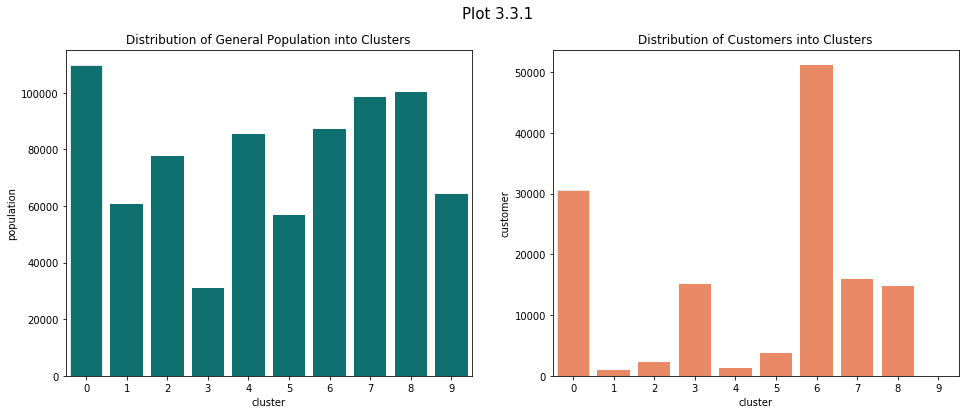

```python
# Visualize dataframe as bar charts
fig = plt.figure(figsize=(16,6))

ax1 = fig.add_subplot(1,2,1)
ax1 = sns.barplot(x=pop_cust_clusters_data_count_df['cluster'],\
                  y=pop_cust_clusters_data_count_df['population'],\
                  color='teal',edgecolor='.9')
plt.title("Distribution of General Population into Clusters")

ax2 = fig.add_subplot(1,2,2)
ax2 = sns.barplot(x=pop_cust_clusters_data_count_df['cluster'],\
                  y=pop_cust_clusters_data_count_df['customer'],\
                  color='coral',edgecolor='.9')

plt.title("Distribution of Customers into Clusters")
plt.suptitle("Plot 3.3.1", fontsize=15);
```

```python
# Add ratio and ratio difference for each cluster to the dataframe
pop_cust_clusters_data_count_df['pop_%'] = (pop_cust_clusters_data_count_df['population']\
                                            /pop_cust_clusters_data_count_df['population'].sum()*100).round(2)
pop_cust_clusters_data_count_df['cust_%'] = (pop_cust_clusters_data_count_df['customer']\
                                             /pop_cust_clusters_data_count_df['customer'].sum()*100).round(2)
pop_cust_clusters_data_count_df['diff'] = pop_cust_clusters_data_count_df['cust_%'] - pop_cust_clusters_data_count_df['pop_%']
pop_cust_clusters_data_count_df
```

|  | cluster | population | customer | pop_% | cust_% | diff |
| --- | --- | --- | --- | --- | --- | --- |
| 0 | 0 | 109743 | 30519 | 14.22 | 22.47 | 8.25 |
| 1 | 1 | 60805 | 1024 | 7.88 | 0.75 | -7.13 |
| 2 | 2 | 77781 | 2286 | 10.08 | 1.68 | -8.40 |
| 3 | 3 | 31045 | 15049 | 4.02 | 11.08 | 7.06 |
| 4 | 4 | 85568 | 1343 | 11.09 | 0.99 | -10.10 |
| 5 | 5 | 56886 | 3673 | 7.37 | 2.70 | -4.67 |
| 6 | 6 | 87248 | 51134 | 11.31 | 37.65 | 26.34 |
| 7 | 7 | 98346 | 15951 | 12.74 | 11.75 | -0.99 |
| 8 | 8 | 100136 | 14811 | 12.98 | 10.91 | -2.07 |
| 9 | 9 | 64143 | 9 | 8.31 | 0.01 | -8.30 |

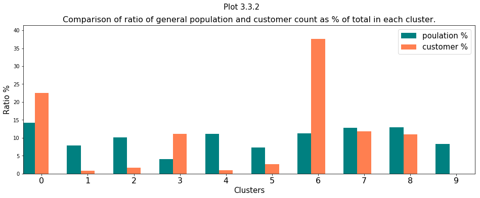

```python
# Visualize ratios for each cluster

fig = plt.figure(figsize=(16,6))

ax = fig.add_subplot(111)

ax = pop_cust_clusters_data_count_df['pop_%'].plot(x=pop_cust_clusters_data_count_df['cluster'], kind='bar',\
                                                   color='teal',width=-0.3, align='edge',position=0)
ax = pop_cust_clusters_data_count_df['cust_%'].plot(x=pop_cust_clusters_data_count_df['cluster'], kind='bar',\
                                                    color='coral',width = 0.3, align='edge',position=1)

ax.margins(x=0.5,y=0.1)
ax.set_xlabel('Clusters', fontsize=15)
ax.set_ylabel('Ratio %', fontsize=15)
ax.xaxis.set(ticklabels= pop_cust_clusters_data_count_df['cluster'])
ax.tick_params(axis = 'x', which = 'major', labelsize = 16)
plt.xticks(rotation=360,)

plt.legend(('poulation %', 'customer %'),fontsize=15)
plt.title(('Comparison of ratio of general population and customer count as % of total in each cluster.')
          ,fontsize=16)

plt.subplots_adjust(bottom=0.2)
plt.suptitle("Plot 3.3.2", fontsize=15)
plt.show()
```

```python
# Missing rows from population dataset
azdias_null_data_row_high.shape[0]
```

```
119520
```

```python
# Missing rows from customer dataset
customers_null_data_row_few = customers[customers.isnull().sum(axis=1) < 9].reset_index(drop=True)
customers_null_data_row_high = customers[customers.isnull().sum(axis=1) >= 9].reset_index(drop=True)
```

```python
customers.shape
```

```
(191652, 79)
```

```python
customers_null_data_row_high.shape
```

```
(55853, 79)
```

```python
customers_null_data_row_few.shape[0] + customers_null_data_row_high.shape[0]
```

```
191652
```

```python
# Add missing data rows as an extra cluster to pop_cust_clusters_data_count_df dataframe
pop_cust_clusters_data_count_df.loc[-1] = ['-1', azdias_null_data_row_high.shape[0],\
                                           customers_null_data_row_high.shape[0],0,0,0]  # adding a row
pop_cust_clusters_data_count_df.index = pop_cust_clusters_data_count_df.index + 1  # shifting index
pop_cust_clusters_data_count_df.sort_index(inplace=True)
```

```python
# Recalculate ratios and differences
pop_cust_clusters_data_count_df['pop_%'] = (pop_cust_clusters_data_count_df['population']\
                                            /pop_cust_clusters_data_count_df['population'].sum()*100).round(2)
pop_cust_clusters_data_count_df['cust_%'] = (pop_cust_clusters_data_count_df['customer']\
                                             /pop_cust_clusters_data_count_df['customer'].sum()*100).round(2)
pop_cust_clusters_data_count_df['diff'] = pop_cust_clusters_data_count_df['cust_%'] - pop_cust_clusters_data_count_df['pop_%']

pop_cust_clusters_data_count_df
```

|  | cluster | population | customer | pop_% | cust_% | diff |
| --- | --- | --- | --- | --- | --- | --- |
| 0 | -1 | 119520 | 55853 | 13.41 | 29.14 | 15.73 |
| 1 | 0 | 109743 | 30519 | 12.31 | 15.92 | 3.61 |
| 2 | 1 | 60805 | 1024 | 6.82 | 0.53 | -6.29 |
| 3 | 2 | 77781 | 2286 | 8.73 | 1.19 | -7.54 |
| 4 | 3 | 31045 | 15049 | 3.48 | 7.85 | 4.37 |
| 5 | 4 | 85568 | 1343 | 9.60 | 0.70 | -8.90 |
| 6 | 5 | 56886 | 3673 | 6.38 | 1.92 | -4.46 |
| 7 | 6 | 87248 | 51134 | 9.79 | 26.68 | 16.89 |
| 8 | 7 | 98346 | 15951 | 11.03 | 8.32 | -2.71 |
| 9 | 8 | 100136 | 14811 | 11.24 | 7.73 | -3.51 |
| 10 | 9 | 64143 | 9 | 7.20 | 0.00 | -7.20 |

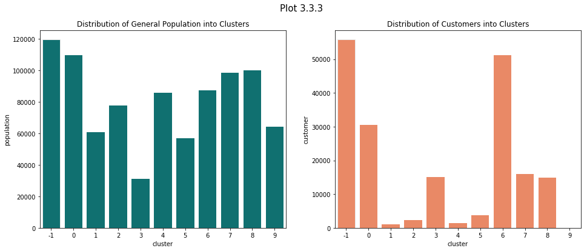

```python
# Re-visualize plot with missing row data added as cluster -1
fig = plt.figure(figsize=(16,6))

ax1 = fig.add_subplot(1,2,1)
ax1 = sns.barplot(x=pop_cust_clusters_data_count_df['cluster'],\
                  y=pop_cust_clusters_data_count_df['population'],\
                  color='teal',edgecolor='.9')
plt.title("Distribution of General Population into Clusters")

ax2 = fig.add_subplot(1,2,2)
ax2 = sns.barplot(x=pop_cust_clusters_data_count_df['cluster'],\
                  y=pop_cust_clusters_data_count_df['customer'],\
                  color='coral',edgecolor='.9')

plt.title("Distribution of Customers into Clusters")
plt.suptitle("Plot 3.3.3", fontsize=15);
```

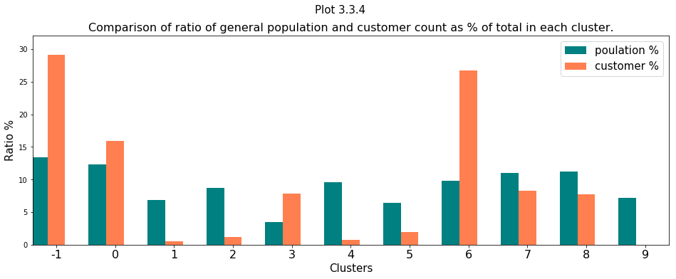

```python
# Re-visualize cluster rations with missing row cluster -1

fig = plt.figure(figsize=(16,6))

ax = fig.add_subplot(111)

ax = pop_cust_clusters_data_count_df['pop_%'].plot(x=pop_cust_clusters_data_count_df['cluster'], kind='bar',\
                                                   color='teal',width=-0.3, align='edge',position=0)
ax = pop_cust_clusters_data_count_df['cust_%'].plot(x=pop_cust_clusters_data_count_df['cluster'], kind='bar',\
                                                    color='coral',width = 0.3, align='edge',position=1)

ax.margins(x=0.5,y=0.1)
ax.set_xlabel('Clusters', fontsize=15)
ax.set_ylabel('Ratio %', fontsize=15)
ax.xaxis.set(ticklabels= pop_cust_clusters_data_count_df['cluster'])
ax.tick_params(axis = 'x', which = 'major', labelsize = 16)
plt.xticks(rotation=360,)

plt.legend(('poulation %', 'customer %'),fontsize=15)
plt.title(('Comparison of ratio of general population and customer count as % of total in each cluster.')
          ,fontsize=16)

plt.subplots_adjust(bottom=0.2)
plt.suptitle("Plot 3.3.4", fontsize=15)
plt.show()
```

From the above visualization, we can observe that there is a proportion difference of +16.89% between customer proportion and genarl population proportion assigned to cluster 6. Therefore, cluster 6 over-represents customer data compared to general population.

Also, we can observe that there is a proportion difference of -8.90% between customer proportion and general population proportion assigned to cluster 4. Therefore, cluster 4 under-represents customer data compared to general population.

```python
# What kinds of people are part of a cluster that is overrepresented in the
# customer data compared to the general population?


# Analysis of principal components of cluster 6 consisting of people with over-representation in the
# customer data compared to the general population.
p_comp_cluster_6 = pd.Series(kmeans_10.cluster_centers_[6])
p_comp_cluster_6.index = p_comp_cluster_6.index + 1
p_comp_cluster_6.sort_values(ascending=False, inplace=True)
p_comp_cluster_6
```

```
5     2.802745
4     2.198747
2     0.894925
23    0.634278
3     0.562757
19    0.287421
15    0.232778
11    0.172864
16    0.160752
25    0.151729
10    0.099723
14    0.055093
27    0.051681
28    0.029503
24    0.015881
```

[output cut: 17 more lines]

```python
azdias.columns
```

```
Index(['ALTERSKATEGORIE_GROB', 'ANREDE_KZ', 'FINANZ_MINIMALIST',
       'FINANZ_SPARER', 'FINANZ_VORSORGER', 'FINANZ_ANLEGER',
       'FINANZ_UNAUFFAELLIGER', 'FINANZ_HAUSBAUER', 'GREEN_AVANTGARDE',
       'HEALTH_TYP',
       ...
       'CAMEO_DEU_2015_9B', 'CAMEO_DEU_2015_9C', 'CAMEO_DEU_2015_9D',
       'CAMEO_DEU_2015_9E', 'PRAEGENDE_JUGENDJAHRE_decade',
       'PRAEGENDE_JUGENDJAHRE_movement', 'CAMEO_INTL_2015_wealth',
       'CAMEO_INTL_2015_life_stage', 'WOHNLAGE_rural',
       'WOHNLAGE_rating_class'],
      dtype='object', length=193)
```

```python
# Transform cluster 6 principal components to original feature values.
p_comp_cluster_6_orig = pd.Series(scaler.inverse_transform(pca_31.inverse_transform(p_comp_cluster_6)))
p_comp_cluster_6_orig = p_comp_cluster_6_orig.round(2)
p_comp_cluster_6_orig.index = azdias.columns
p_comp_cluster_6_orig
```

```
ALTERSKATEGORIE_GROB              3.03
ANREDE_KZ                         1.47
FINANZ_MINIMALIST                 2.79
FINANZ_SPARER                     2.73
FINANZ_VORSORGER                  3.59
FINANZ_ANLEGER                    2.54
FINANZ_UNAUFFAELLIGER             2.54
FINANZ_HAUSBAUER                  3.29
GREEN_AVANTGARDE                  0.24
HEALTH_TYP                        2.40
RETOURTYP_BK_S                    4.08
SEMIO_SOZ                         4.79
SEMIO_FAM                         4.06
SEMIO_REL                         3.56
SEMIO_MAT                         3.15
SEMIO_VERT                        4.32
SEMIO_LUST                        4.74
SEMIO_ERL                         4.95
SEMIO_KULT                        4.07
SEMIO_RAT                         3.44
SEMIO_KRIT                        4.53
SEMIO_DOM                         4.74
SEMIO_KAEM                        4.51
SEMIO_PFLICHT                     3.86
SEMIO_TRADV                       3.51
SOHO_KZ                          -0.03
VERS_TYP                          1.80
ANZ_PERSONEN                      1.82
ANZ_TITEL                        -0.05
HH_EINKOMMEN_SCORE                5.11
                                  ...
CAMEO_DEU_2015_5C                -0.01
CAMEO_DEU_2015_5D                 0.05
CAMEO_DEU_2015_5E                -0.01
CAMEO_DEU_2015_5F                 0.00
CAMEO_DEU_2015_6A                -0.03
CAMEO_DEU_2015_6B                -0.01
CAMEO_DEU_2015_6C                 0.04
CAMEO_DEU_2015_6D                 0.04
CAMEO_DEU_2015_6E                 0.04
CAMEO_DEU_2015_6F                 0.01
CAMEO_DEU_2015_7A                -0.06
CAMEO_DEU_2015_7B                 0.09
CAMEO_DEU_2015_7C                 0.07
CAMEO_DEU_2015_7D                 0.02
CAMEO_DEU_2015_7E                 0.05
CAMEO_DEU_2015_8A                 0.11
CAMEO_DEU_2015_8B                -0.03
CAMEO_DEU_2015_8C                 0.18
CAMEO_DEU_2015_8D                 0.11
CAMEO_DEU_2015_9A                 0.16
CAMEO_DEU_2015_9B                 0.09
CAMEO_DEU_2015_9C                 0.04
CAMEO_DEU_2015_9D                 0.10
CAMEO_DEU_2015_9E                 0.03
PRAEGENDE_JUGENDJAHRE_decade      4.36
PRAEGENDE_JUGENDJAHRE_movement    0.76
CAMEO_INTL_2015_wealth            4.95
CAMEO_INTL_2015_life_stage        3.22
WOHNLAGE_rural                    0.13
WOHNLAGE_rating_class             2.97
Length: 193, dtype: float64
```

```python
# Analyze top principal component in cluster 6
# Getting top 5 positive and negative weights of a principal component 5.
weights_sorted_p_comp(5, 5)
```

```
Principal Component 5
------------------------------

Top positive weights are below

GREEN_AVANTGARDE       0.2277
ANREDE_KZ              0.2000
LP_STATUS_GROB_5.0     0.1931
LP_STATUS_FEIN_10.0    0.1931
SEMIO_DOM              0.1860
Name: PC 5, dtype: float64
------------------------------

Top negative weights are below

PRAEGENDE_JUGENDJAHRE_movement   -0.2277
W_KEIT_KIND_HH                   -0.1937
SEMIO_FAM                        -0.1783
BALLRAUM                         -0.1590
LP_STATUS_GROB_4.0               -0.1403
Name: PC 5, dtype: float64
```

```python
# Analyze second top principal component in cluster 6
# Getting top 5 positive and negative weights of a principal component 4.
weights_sorted_p_comp(4, 5)
```

```
Principal Component 4
------------------------------

Top positive weights are below

EWDICHTE              0.2066
GREEN_AVANTGARDE      0.1868
FINANZTYP_4           0.1866
LP_STATUS_FEIN_5.0    0.1799
SEMIO_FAM             0.1708
Name: PC 4, dtype: float64
------------------------------

Top negative weights are below

HH_EINKOMMEN_SCORE               -0.2217
PRAEGENDE_JUGENDJAHRE_movement   -0.1868
WOHNLAGE_rural                   -0.1699
ANREDE_KZ                        -0.1667
KONSUMNAEHE                      -0.1550
Name: PC 4, dtype: float64
```

```python
# What kinds of people are part of a cluster that is underrepresented in the
# customer data compared to the general population?

# Analysis of principal components of cluster 4 consisting of people with under-representation in the
# customer data compared to the general population.
p_comp_cluster_4 = pd.Series(kmeans_10.cluster_centers_[4])
p_comp_cluster_4.index = p_comp_cluster_4.index + 1
p_comp_cluster_4.sort_values(ascending=False, inplace=True)
p_comp_cluster_4
```

```
1     4.923229
5     1.928643
12    0.511055
25    0.338480
10    0.324018
21    0.170202
26    0.165467
11    0.151599
17    0.142274
19    0.093840
22    0.062822
13    0.015764
18    0.012715
27    0.003285
31   -0.019860
```

[output cut: 17 more lines]

```python
# Transform cluster 4 principal components to original feature values.
p_comp_cluster_4_orig = pd.Series(scaler.inverse_transform(pca_31.inverse_transform(p_comp_cluster_4)))
p_comp_cluster_4_orig = p_comp_cluster_4_orig.round(2)
p_comp_cluster_4_orig.index = azdias.columns
p_comp_cluster_4_orig
```

```
ALTERSKATEGORIE_GROB              2.69
ANREDE_KZ                         1.52
FINANZ_MINIMALIST                 2.10
FINANZ_SPARER                     3.12
FINANZ_VORSORGER                  3.43
FINANZ_ANLEGER                    2.85
FINANZ_UNAUFFAELLIGER             2.78
FINANZ_HAUSBAUER                  4.05
GREEN_AVANTGARDE                  0.08
HEALTH_TYP                        2.51
RETOURTYP_BK_S                    3.95
SEMIO_SOZ                         4.22
SEMIO_FAM                         4.43
SEMIO_REL                         4.32
SEMIO_MAT                         3.76
SEMIO_VERT                        3.77
SEMIO_LUST                        4.25
SEMIO_ERL                         4.47
SEMIO_KULT                        4.12
SEMIO_RAT                         3.91
SEMIO_KRIT                        4.91
SEMIO_DOM                         4.92
SEMIO_KAEM                        4.77
SEMIO_PFLICHT                     4.39
SEMIO_TRADV                       3.70
SOHO_KZ                           0.00
VERS_TYP                          1.81
ANZ_PERSONEN                      1.35
ANZ_TITEL                        -0.04
HH_EINKOMMEN_SCORE                5.49
                                  ...
CAMEO_DEU_2015_5C                -0.01
CAMEO_DEU_2015_5D                 0.04
CAMEO_DEU_2015_5E                -0.00
CAMEO_DEU_2015_5F                 0.00
CAMEO_DEU_2015_6A                 0.00
CAMEO_DEU_2015_6B                 0.02
CAMEO_DEU_2015_6C                 0.03
CAMEO_DEU_2015_6D                 0.02
CAMEO_DEU_2015_6E                 0.04
CAMEO_DEU_2015_6F                 0.01
CAMEO_DEU_2015_7A                 0.01
CAMEO_DEU_2015_7B                 0.08
CAMEO_DEU_2015_7C                 0.03
CAMEO_DEU_2015_7D                 0.01
CAMEO_DEU_2015_7E                 0.02
CAMEO_DEU_2015_8A                 0.12
CAMEO_DEU_2015_8B                 0.07
CAMEO_DEU_2015_8C                 0.11
CAMEO_DEU_2015_8D                 0.07
CAMEO_DEU_2015_9A                 0.12
CAMEO_DEU_2015_9B                 0.10
CAMEO_DEU_2015_9C                 0.06
CAMEO_DEU_2015_9D                 0.09
CAMEO_DEU_2015_9E                 0.04
PRAEGENDE_JUGENDJAHRE_decade      4.60
PRAEGENDE_JUGENDJAHRE_movement    0.92
CAMEO_INTL_2015_wealth            5.14
CAMEO_INTL_2015_life_stage        2.19
WOHNLAGE_rural                   -0.03
WOHNLAGE_rating_class             3.51
Length: 193, dtype: float64
```

```python
# Analyze top principal component in cluster 4
# Getting top 5 positive and negative weights of a principal component 1.
weights_sorted_p_comp(1, 5)
```

```
Principal Component 1
------------------------------

Top positive weights are below

CAMEO_INTL_2015_wealth    0.1852
PLZ8_ANTG3                0.1843
LP_STATUS_GROB_1.0        0.1792
EWDICHTE                  0.1633
ORTSGR_KLS9               0.1565
Name: PC 1, dtype: float64
------------------------------

Top negative weights are below

FINANZ_MINIMALIST   -0.1899
MOBI_REGIO          -0.1879
PLZ8_ANTG1          -0.1822
KBA05_ANTG1         -0.1816
KBA05_GBZ           -0.1780
Name: PC 1, dtype: float64
```

```python
# Analyze top principal component in cluster 4
# Getting second top 5 positive and negative weights of a principal component 5.
weights_sorted_p_comp(5, 5)
```

```
Principal Component 5
------------------------------

Top positive weights are below

GREEN_AVANTGARDE       0.2277
ANREDE_KZ              0.2000
LP_STATUS_GROB_5.0     0.1931
LP_STATUS_FEIN_10.0    0.1931
SEMIO_DOM              0.1860
Name: PC 5, dtype: float64
------------------------------

Top negative weights are below

PRAEGENDE_JUGENDJAHRE_movement   -0.2277
W_KEIT_KIND_HH                   -0.1937
SEMIO_FAM                        -0.1783
BALLRAUM                         -0.1590
LP_STATUS_GROB_4.0               -0.1403
Name: PC 5, dtype: float64
```

### Discussion 3.3: Compare Customer Data to Demographics Data

#### Compare the Population and Customer clusters without consideration of the missing row data.

If we compare the Population and Customer clusters without consideration of the missing row data, we can observe the below -

General Population dataset has highest count(109743) of observations in cluster 0 and has lowest count(31045) of observations in cluster 3. Customer dataset has highest count(51134) of observations in cluster 6 and lowest count(9) in cluster 9.

From plot 3.3.1, we can observe that there is a difference in the cluster distributions between the general population and the customer dataset. Looking at the ratios of each cluster against total counts in order to make better comparisons, we can see the customer dataset is over-represented in clusters 0,3 and 6 with greater than 5% ratio difference to the general population, and under-represented in clusters 1, 2, 4 and 9 with 5% ratio difference to the general population.

This can be seen in Plot 3.3.2, where the significance of cluster 6 customer segment to the mail order company's customer base is clearly visible.

However, to make this analysis more complete, we should also include the missing row data as an additional cluster. In step 1.1.3 we found that the rows of missing data were qualitatively different to the the rows kept for the analysis.

#### Compare the Population and Customer clusters with consideration of the missing row data.

If we compare the Population and Customer clusters with consideration of the missing row data, we can observe the below -

we have assigned missing row data to cluster -1.

Plots 3.3.3 and 3.3.4 are the same visualizations as 3.3.1 and 3.3.2 respectively with the missing row data added as cluster -1. We can see the impact is significant.

General Population dataset has 119520 rows with missing data(where number of missing values in each row is greater than 8). The missing row data for the population dataset represented 13.41% of the total population data.

Customer dataset has 55853 rows with missing data(where number of missing values in each row is greater than 8). The missing row data for the customer dataset represented 29.14% of the total customer data.

If we take +5% threshold of ratio difference for determining over-representation and -5% threshold of ratio difference for determining under-representation, the customer dataset is over-represented in cluster -1(15.73%) and cluster 6(16.89), and under-represented in clusters 1(-6.29), 2(-7.54), 4(-8.90) and 9(-7.20).

So, from the above, customer data is over-represented in cluster 6 and under-represented in cluster 4.

The missing row data requires more investigation and analysis but from the preliminary bar charts constructed in step 1.1.3, this data seems to represent conservative, minimilistic high-income earners receptive to advertising incentives and is a relevant customer segment for targeting for the mail order company.

#### Analysis for Cluster that is over-represented in the customer data is below -

Cluster 6 is the most relevant cluster for the mail order company's customer base. If we analyze the features that make up this cluster by inverse transforming the principal components and inverse scaling we obtain values for the cluster centroid for our original features(after data wrangling step earlier) that we can use to create a picture of the customer segment. We can also determine the most important features by looking at the principal components that have the biggest impact on the cluster and then analyzing which features make up the largest positive and negative weights of this principal component as we did in step 2.3.

Looking at the top five positive & negative weights for component 5 and their original feature value from the inverse transformation:

Top 5 positive weights for component 5 are -

Top 5 negative weights for component 5 are -

PRAEGENDE_JUGENDJAHRE_movement, feature value = 0.76, signifies movement of person's youth(Mainstream) W_KEIT_KIND_HH, feature value = 4.71, signifies Likelihood of children in household(unlikely) SEMIO_FAM, feature value = 4.05, signifies family-minded individuals with average affinity BALLRAUM, feature value = 3.29, signifies Distance to nearest urban center(20-30 km) LP_STATUS_GROB_4.0, feature value = 0.08, signifies not houseowners

Looking at the top five positive & negative weights for component 4 and their original feature value from the inverse transformation:

Top 5 positive weights for component 4 are -

Top 5 negative weights for component 4 are -

HH_EINKOMMEN_SCORE, feature value = 5.11, signifies low household net income PRAEGENDE_JUGENDJAHRE_movement, feature = 0.76, signifies movement of person's youth(Mainstream) WOHNLAGE_rural, feature value = 0.13, signifies neighbourhood quality without score ANREDE_KZ, feature value = 1.47, signifies gender as male KONSUMNAEHE, feature value = 1.62, signifies building is located in a 250 x 250m grid cell

#### Analysis for Cluster that is under-represented in the customer data is below -

Cluster 4 is the least relevant customer segment for the company. The main principal component is number component 1 that has a value of 4.92 followed by component number 5, 12, 25 and 10 with values of 1.92, 0.51, 0.33 and 0.32 respectively. From this we can see principal components 1 has the biggest influence. Following the same process of analysis as above to form a picture of this under-represented group.

Looking at the top five positive & neagtive weights for component 1 and their original feature value from the inverse transformation:

Top 5 positive weights for component 1 are -

CAMEO_INTL_2015_wealth, feature value = 5.13, signifies poorer households PLZ8_ANTG3, feature value = 2.89, signifies high share of 6-10 family homes LP_STATUS_GROB_1.0, feature value = 0.76, signifies low-income earners EWDICHTE, feature value = 5.70, more than 999 households per square km ORTSGR_KLS9, feature value = 7.32, signifies large size of community(100,001 to 300,000 inhabitants)

Top 5 negative weights for component 1 are -

FINANZ_MINIMALIST, feature value = 2.10, signifies high earners MOBI_REGIO, fetaure value = 1.21, signifies very high movement patterns PLZ8_ANTG1, feature value = 1.02, signifreis lower share of 1-2 family homes KBA05_ANTG1, feature value = -0.08, signifies no 3-5 family homes KBA05_GBZ, feature value = 1.86, signifies 3-4 buildings in the microcell

Top 5 positive weights for component 5 are -

GREEN_AVANTGARDE, feature value = 0.08, signifies not a member of green avantgarde ANREDE_KZ, feature value = 1.52, signifies gender as female LP_STATUS_GROB_5.0, feature value = -0.02, signifies not top earners LP_STATUS_FEIN_10.0, feature value = -0.02, signifies not top earners SEMIO_DOM, feature value = 4.91, signifies dominant-minded individuals with low affinity

Top 5 negative weights for component 5 are -

PRAEGENDE_JUGENDJAHRE_movement, feature value = 0.92, signifies movement of person's youth(Mainstream) W_KEIT_KIND_HH, feature value = 5.05, signifies Likelihood of children in household(unlikely) SEMIO_FAM, fetaure value = 4.42, signifies family-minded individuals with average affinity BALLRAUM, fetuare value = 3.00, signifies Distance to nearest urban center(20-30 km) LP_STATUS_GROB_4.0, feature value = -0.05, signifies not houseowners

**From the above details we can start to form a picture of the lowest customer segment group for the mail order company. They are low income earners mostly females with poorer household, not house owners and belong to high density populated area with large size of the community i.e. they belong to dense urban towns and small cities with buildings that contain many apartments.**

> Congratulations on making it this far in the project! Before you finish, make sure to check through the entire notebook from top to bottom to make sure that your analysis follows a logical flow and all of your findings are documented in **Discussion** cells. Once you've checked over all of your work, you should export the notebook as an HTML document to submit for evaluation. You can do this from the menu, navigating to **File -> Download as -> HTML (.html)**. You will submit both that document and this notebook for your project submission.